# SENDAs Agreement 1 Update 2010-2022

```r
map_c4 <- c(
  "codigo_identificacion"                               = "codigoidentificacion",
  "nombre_centro"                                       = "nombrecentro",
  "tipo_centro"                                         = "tipocentro",
  "region_del_centro"                                   = "regiondelcentro",
  "fecha_nacimiento"                                    = "fechanacimiento",
  "fecha_ingreso_a_tratamiento"                         = "fechaingresotratamiento",
  "tipo_de_programa"                                    = "tipoprograma",
  "tipo_de_plan"                                        = "tipoplan",
  "origen_de_ingreso"                                   = "origendeingreso",
  "consentimiento_informado"                            = "consentimientoinformado",
  "pais_nacimiento"                                     = "paisnacimiento",
  "estado_conyugal"                                     = "estadoconyugal",
  "numero_de_hijos"                                     = "numerodehijos",
  "escolaridad_ultimo_ano_cursado"                      = "escolaridadultimoaa_ocursado",
  "se_trata_de_una_mujer_embarazada"                    = "setratadeunamujerembarazada",
  "condicion_ocupacional"                               = "condicionocupacional",
  "categoria_ocupacional"                               = "categoriaocupacional",
  "rubro_trabaja"                                       = "enquerubrotrabaja",
  "con_quien_vive"                                      = "conquienvive",
  "parentesco_con_el_jefe_de_hogar"                     = "parentescoconeljefedehogar",
  "tipo_de_vivienda"                                    = "tipovivienda",
  "tenencia_de_la_vivienda"                             = "tenenciadelavivienda",
  "numero_de_tratamientos_anteriores"                   = "numerotratamientosanteriores",
  "fecha_ultimo_tratamiento"                            = "fechaultimotratamiento",
  "sustancia_principal"                                 = "sustanciaprincipal",
  "otras_sustancias_no1"                                = "otrasustanci_an1",
  "otras_sustancias_no2"                                = "otrasustanci_an2",
  "frecuencia_de_consumo_sustancia_principal"           = "frecuenciadeconsumosustancia",
  "via_administracion_sustancia_principal"              = "viadeadministracionsustancia",
  "sustancia_de_inicio"                                 = "sustanciadeinicio",
  "edad_inicio_consumo"                                 = "edaddeiniciosustanciainicia",
  "edad_inicio_sustancia_principal"                     = "edaddeinico_sustancia_principa",
  "diagnostico_trs_consumo_sustancia"                   = "diagnosticotrsconsumosustanc",
  "diagnostico_trs_psiquiatrico_cie_10"                 = "diagnosticotrspsiquiatricoci",
  "diagnostico_trs_psiquiatrico_dsm_iv"                 = "diagnosticotrspsiquiatricods",
  "diagnostico_trs_fisico"                              = "diagnosticotrsfisico",
  "otros_problemas_de_atencion_de_salud_mental"         = "otrosproblemasdeatenciondes",
  "compromiso_biopsicosocial"                           = "comprimisobiopsicosocial",
  "fecha_egreso_de_tratamiento"                         = "fechaegresotratamiento",
  "motivo_de_egreso"                                    = "motivodeegreso",
  "evaluacion_del_proceso_terapeutico"                  = "evaluaciondelprocesoterapeuti",
  "evaluacion_al_egreso_respecto_al_patron_de_consumo"  = "evaluacionalegresorespectoal",
  "evaluacion_al_egreso_respecto_a_situacion_familiar"  = "evaluacionalegresorespectoa",
  "evaluacion_al_egreso_respecto_relaciones_interpersonales" = "evaluacionalegresorespectore",
  "dias_en_tratamiento"                                 = "diasdetratamiento",
  "ha_estado_embarazada_egreso"                         = "haestadoembarazadaegreso",
  "identidad_de_genero"                                 = "identidaddegenero",
  "orientacion_sexual"                                  = "orientacion_sexual",
  "opcion_discapacidad"                                 = "opciondiscapacidad"
)
CONS_C4_25 <- rename_if_present_to_main(CONS_C4_25, map_c4, MAIN_NAMES)
CONS_C4_25 <- replace_columns_if_any(
    df = CONS_C4_25,
    x = "ao",
    y = "diagnostico_trs_psiquiatrico_cie_10_2"
)
CONS_C4_25 <- replace_columns_if_any(
    df = CONS_C4_25,
    x = "ap",
    y = "diagnostico_trs_psiquiatrico_cie_10_3"
)
CONS_C4_25 <- replace_columns_if_any(
    df = CONS_C4_25,
    x = "ar",
    y = "diagnostico_trs_psiquiatrico_dsm_iv_2"
)
CONS_C4_25 <- replace_columns_if_any(
    df = CONS_C4_25,
    x = "as",
    y = "diagnostico_trs_psiquiatrico_dsm_iv_3"
)
CONS_C4_25 <- replace_columns_if_any(
    df = CONS_C4_25,
    x = "av",
    y = "otros_problemas_de_atencion_de_salud_mental_2"
)
CONS_C4_25 <- replace_columns_if_any(
    df = CONS_C4_25,
    x = "ba",
    y = "tiempodepermanenciaprivadode_meses"
)
CONS_C4_25 <- replace_columns_if_any(
    df = CONS_C4_25,
    x = "bb",
    y = "tiempodepermanenciaprivadode_anos"
)
CONS_C4_25 <- replace_columns_if_any(
    df = CONS_C4_25,
    x = "bf",
    y = "diagnostico_trs_psiquiatrico_cie_10_al_egreso"
)
CONS_C4_25 <- replace_columns_if_any(
    df = CONS_C4_25,
    x = "bj",
    y = "evaluacion_al_egreso_respecto_a_situacion_ocupacional"
)
CONS_C4_25 <- replace_columns_if_any(
    df = CONS_C4_25,
    x = "bk",
    y = "evaluacion_al_egreso_respecto_salud_mental"
)
CONS_C4_25 <- replace_columns_if_any(
    df = CONS_C4_25,
    x = "bl",
    y = "evaluacion_al_egreso_respecto_salud_fisica"
)
CONS_C4_25 <- replace_columns_if_any(
    df = CONS_C4_25,
    x = "bm",
    y = "evaluacion_al_egreso_respecto_trasgresion_a_la_norma_social"
)

map_c5 <- c(
  "codigo_identificacion"                               = "codigo_identificaci_afn",
  "tipo_centro"                                         = "tipode_centro",
  "region_del_centro"                                   = "regi_afn_centro",
  "comuna_residencia"                                   = "comuna_usuario",# suposed commune of user
  "servicio_de_salud"                                   = "servicio_salud",
  "tipo_de_plan"                                        = "tipode_plan",
  "dias_en_tratamiento"                                 = "diasen_tratamiento",
  "fecha_nacimiento"                                    = "fechanacimiento",
  "n_meses_en_tratamiento"                              = "n_meses_tratamiento",
  "fecha_ingreso_a_tratamiento"                         = "fecha_ingreso_tratamiento",
  "origen_de_ingreso"                                   = "origen_ingreso",
  "numero_de_hijos"                                     = "n_afomerodehijos",
  "via_administracion_sustancia_principal"              = "via_administraci_afn",
  "fecha_egreso_de_tratamiento"                         = "fecha_egreso",
  "motivo_de_egreso"                                    = "motivo_egreso",
  "otros_problemas_de_atencion_de_salud_mental"         = "otros_problemasde_atenci_afnde",
  "evaluacion_del_proceso_terapeutico_e"                = "evaluacion_proceso_terapeutico_e",
  "evaluacion_al_egreso_respecto_al_patron_de_consumo"  = "patronde_consumo",
  "evaluacion_al_egreso_respecto_a_situacion_familiar"  = "situacion_familiar",
  "evaluacion_al_egreso_respecto_relaciones_interpersonales" = "relacion_interpesonal",
  "evaluacion_al_egreso_respecto_a_situacion_ocupacional"    = "situacion_ocupacional",
  "evaluacion_al_egreso_respecto_salud_mental"          = "salud_mental",
  "evaluacion_al_egreso_respecto_salud_fisica"          = "salud_fisica",
  "diagnostico_trs_consumo_sustancia"                   = "diagn_afstico_trs_consumode_sus",
  "diagnostico_trs_fisico"                              = "diagn_afstico_trs_f_afsico",
  "diagnostico_trs_psiquiatrico_dsm_iv"                 = "diagn_afstico_trs_psiqui_aftrico",
  "diagnostico_trs_psiquiatrico_dsm_iv_2"               = "diagn_afstico_trs_psiqui_aftric",
  "motivodeegreso_alta_administra"                      = "motivo_de_egreso_alta_administrativa",
  "orientacion_sexual"                                  = "orientaci_afn_sexual",
  "opcion_discapacidad"                                 = "opci_afndiscapacidad",
  "id_centro"                                           = "centro_id",
  "identidad_de_genero"                                 = "identidaddegenero",
  "ha_estado_embarazada_egreso"                         = "haestadoembarazadaegreso"
)
CONS_C5_25 <- rename_if_present_to_main(CONS_C5_25, map_c5, MAIN_NAMES)
CONS_C5_25 <- replace_columns_if_any(
    df = CONS_C5_25,
    x = "s",
    y = "enlo_penal_2"
)
CONS_C5_25 <- replace_columns_if_any(
    df = CONS_C5_25,
    x = "be",
    y = "diagnostico_trs_psiquiatrico_sub_dsm_iv"
)
CONS_C5_25 <- replace_columns_if_any(
    df = CONS_C5_25,
    x = "bg",
    y = "diagnostico_trs_psiquiatrico_sub_dsm_iv_2"
)
CONS_C5_25 <- replace_columns_if_any(
    df = CONS_C5_25,
    x = "bh",
    y = "diagnostico_trs_psiquiatrico_cie_10"
)
CONS_C5_25 <- replace_columns_if_any(
    df = CONS_C5_25,
    x = "bi",
    y = "diagnostico_trs_psiquiatrico_sub_cie_10"
)
CONS_C5_25 <- replace_columns_if_any(
    df = CONS_C5_25,
    x = "bj",
    y = "diagnostico_trs_psiquiatrico_cie_10_2"
)
CONS_C5_25 <- replace_columns_if_any(
    df = CONS_C5_25,
    x = "bk",
    y = "diagnostico_trs_psiquiatrico_sub_cie_10_2"
)
CONS_C5_25 <- replace_columns_if_any(
    df = CONS_C5_25,
    x = "bm",
    y = "otros_problemas_de_atencion_de_salud_mental_2"
)
```

```r
map_c6 <- c(
  "codigo_identificacion"                               = "codigoidentificacion",
  "nombre_centro"                                       = "nombredelcentro",
  "tipo_centro"                                         = "tipocentro",
  "region_del_centro"                                   = "regiondelcentro",
  "fecha_ingreso_a_tratamiento"                         = "fechaingresotratamiento",
  "dias_en_tratamiento"                                 = "diasen_tratamiento",
  "n_meses_en_tratamiento"                              = "n_mesesen_tratamiento",
  "fecha_nacimiento"                                    = "fechanacimiento",
  "consentimiento_informado"                            = "consentimientoinformado",
  "comuna_residencia"                                   = "comuna",# suposed commune of user
  "origen_de_ingreso"                                   = "origendeingreso",
  "pais_nacimiento"                                     = "paisnacimiento",
  "estado_conyugal"                                     = "estadoconyugal",
  "numero_de_hijos"                                     = "numerodehijos",
  "escolaridad_ultimo_ano_cursado"                      = "escolaridadultimoaa_ocursado",
  "se_trata_de_una_mujer_embarazada"                    = "setratadeunamujerembarazada",
  "condicion_ocupacional"                               = "condicionocupacional",
  "categoria_ocupacional"                               = "categoriaocupacional",
  "con_quien_vive"                                      = "conquienviva_a",
  "parentesco_con_el_jefe_de_hogar"                     = "parentescoconeljefedehogar",
  "tipo_de_vivienda"                                    = "tipovivienda",
  "tenencia_de_la_vivienda"                             = "tenenciadelavivienda",
  "numero_de_tratamientos_anteriores"                   = "numerotratamientosanteriores",
  "fecha_ultimo_tratamiento"                            = "fechaultimotratamiento",
  "sustancia_principal"                                 = "sustanciaprincipal",
  "otras_sustancias_no1"                                = "otrasustanci_an1",
  "otras_sustancias_no2"                                = "otrasustanci_an2",
  "frecuencia_de_consumo_sustancia_principal"           = "frecuenciadeconsumosustancia",
  "edad_inicio_sustancia_principal"                     = "edaddeiniciosustanciaprinci",
  "via_administracion_sustancia_principal"              = "viadeadministracionsustancia",
  "sustancia_de_inicio"                                 = "sustanciadeinicio",
  "edad_inicio_consumo"                                 = "edaddeiniciosustanciainicia",
  "diagnostico_trs_consumo_sustancia"                   = "diagnosticotrsconsumosustanc",
  "diagnostico_trs_psiquiatrico_cie_10"                 = "diagnosticotrspsiquiatricoci",
  "diagnostico_trs_psiquiatrico_dsm_iv"                 = "diagnosticotrspsiquiatricods",
  "otros_problemas_de_atencion_de_salud_mental"         = "otrosproblemasdeatenciondes",
  "compromiso_biopsicosocial"                           = "comprimisobiopsicosocial",
  "fecha_egreso_de_tratamiento"                         = "fechaegresotratamiento",
  "motivo_de_egreso"                                    = "motivodeegreso",
  "evaluacion_del_proceso_terapeutico"                  = "evaluaciondelprocesoterapeuti",
  "evaluacion_al_egreso_respecto_al_patron_de_consumo"  = "evaluacionalegresorespectoal",
  "evaluacion_al_egreso_respecto_a_situacion_familiar"  = "evaluacionalegresorespectoa",
  "evaluacion_al_egreso_respecto_relaciones_interpersonales" = "evaluacionalegresorespectore",
  "motivo_de_egreso_alta_administrativa"                = "motivoaltaadministrativa",
  "ha_estado_embarazada_egreso"                         = "haestadoembarazadaegreso",
  "identidad_de_genero"                                 = "identidaddegenero",
  "orientacion_sexual"                                  = "orientacion_sexual",
  "opcion_discapacidad"                                 = "opciondiscapacidad"
)
CONS_C6_25 <- rename_if_present_to_main(CONS_C6_25, map_c6, MAIN_NAMES)

CONS_C6_25 <- replace_columns_if_any(
    df = CONS_C6_25,
    x = "an",
    y = "frecuencia_de_consumo_sustancia_principal_medio_cerrado"
)

CONS_C6_25 <- replace_columns_if_any(
    df = CONS_C6_25,
    x = "au",
    y = "diagnostico_trs_psiquiatrico_cie_10_2"
)
CONS_C6_25 <- replace_columns_if_any(
    df = CONS_C6_25,
    x = "av",
    y = "diagnostico_trs_psiquiatrico_cie_10_3"
)
CONS_C6_25 <- replace_columns_if_any(
    df = CONS_C6_25,
    x = "ax",
    y = "diagnostico_trs_psiquiatrico_dsm_iv_2"
)
CONS_C6_25 <- replace_columns_if_any(
    df = CONS_C6_25,
    x = "ay",
    y = "diagnostico_trs_psiquiatrico_dsm_iv_3"
)
CONS_C6_25 <- replace_columns_if_any(
    df = CONS_C6_25,
    x = "ba",
    y = "otros_problemas_de_atencion_de_salud_mental_2"
)
CONS_C6_25 <- replace_columns_if_any(
    df = CONS_C6_25,
    x = "bn",
    y = "diagnostico_trs_psiquiatrico_cie_10_al_egreso"
)
CONS_C6_25 <- replace_columns_if_any(
    df = CONS_C6_25,
    x = "br",
    y = "evaluacion_al_egreso_respecto_a_situacion_ocupacional"
)
CONS_C6_25 <- replace_columns_if_any(
    df = CONS_C6_25,
    x = "bs",
    y = "evaluacion_al_egreso_respecto_salud_mental"
)
CONS_C6_25 <- replace_columns_if_any(
    df = CONS_C6_25,
    x = "bt",
    y = "evaluacion_al_egreso_respecto_salud_fisica"
)
CONS_C6_25 <- replace_columns_if_any(
    df = CONS_C6_25,
    x = "bu",
    y = "evaluacion_al_egreso_respecto_trasgresion_a_la_norma_social"
)
```

```r
CONS_C6_25$edad_ingreso<-
  lubridate::time_length(
    interval(
      as.Date(CONS_C6_25$fechanacimiento, format = "%d/%m/%Y"),
      as.Date(CONS_C6_25$fecha_ingreso_a_tratamiento, format = "%d/%m/%Y")
    ),
    unit = "year"
  )

# Create the histograms for each dataset
hist_c2 <- ggplot(CONS_C2_25, aes(x = edad)) +
  geom_histogram(fill = "gray70", color = "black", bins = 30) +
  ggtitle("c2")+ theme_bw()+ xlim(0,90)

hist_c3 <- ggplot(CONS_C3_25, aes(x = edad)) +
  geom_histogram(fill = "gray70", color = "black", bins = 30) +
  ggtitle("c3")+ theme_bw()+ xlim(0,90)

hist_c4 <- ggplot(CONS_C4_25, aes(x = edad)) +
  geom_histogram(fill = "gray70", color = "black", bins = 30) +
  ggtitle("c4")+ theme_bw()+ xlim(0,90)

hist_c5 <- ggplot(CONS_C5_25, aes(x = edad)) +
  geom_histogram(fill = "gray70", color = "black", bins = 30) +
  ggtitle("c5")+ theme_bw()+ xlim(0,90)

hist_c6 <- ggplot(CONS_C6_25, aes(x = edad_ingreso)) +
  geom_histogram(fill = "gray70", color = "black", bins = 30) +
  ggtitle("c6")+ theme_bw()+ xlim(0,90)

# Combine histograms into a single plot
combined_plot <- ggpubr::ggarrange(hist_c2, hist_c3, hist_c4, hist_c5, hist_c6, ncol = 3, nrow = 2)
```

Warning: Removed 2 rows containing non-finite outside the scale range (`stat_bin()`).

Warning: Removed 2 rows containing missing values or values outside the scale range (`geom_bar()`). Removed 2 rows containing missing values or values outside the scale range (`geom_bar()`).

Warning: Removed 2 rows containing non-finite outside the scale range (`stat_bin()`).

Warning: Removed 2 rows containing missing values or values outside the scale range (`geom_bar()`).

Warning: Removed 1 row containing non-finite outside the scale range (`stat_bin()`).

Warning: Removed 2 rows containing missing values or values outside the scale range (`geom_bar()`). Removed 2 rows containing missing values or values outside the scale range (`geom_bar()`).

Histograms for Age

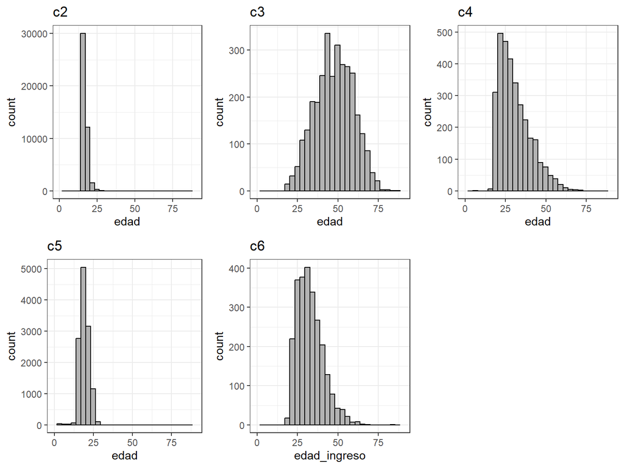

```r
# Display the combined plot
print(combined_plot)
```

```r
# Get the column names for each dataset
names_c2 <- names(CONS_C2_25)
names_c3 <- names(CONS_C3_25)
names_c4 <- names(CONS_C4_25)
names_c5 <- names(CONS_C5_25)
names_c6 <- names(CONS_C6_25)

df_c2 <- data.frame(Dataset = "CONS_C2", Column_Name = names_c2)
df_c3 <- data.frame(Dataset = "CONS_C3", Column_Name = names_c3)
df_c4 <- data.frame(Dataset = "CONS_C4", Column_Name = names_c4)
df_c5 <- data.frame(Dataset = "CONS_C5", Column_Name = names_c5)
df_c6 <- data.frame(Dataset = "CONS_C6", Column_Name = names_c6)

dplyr::full_join(df_c2, df_c3, by = "Column_Name") %>%
    dplyr::full_join(df_c4, by = "Column_Name") %>%
    dplyr::full_join(df_c5, by = "Column_Name") %>%
    dplyr::full_join(df_c6, by = "Column_Name") %>%
    dplyr::arrange(Column_Name) -> joined_df

joined_df %>%
  dplyr::select(Column_Name, everything()) %>%
  dplyr::arrange(Column_Name) %>%
  dplyr::rename("c2"="Dataset.x","c3"="Dataset.y", "c4"="Dataset.x.x", "c5"="Dataset.y.y","c6"="Dataset") %>%
  dplyr::mutate_at(.vars = vars(matches("c[0-9]$")),
                        .funs = ~ ifelse(!is.na(.), "X", "")) %>%
  kbl("markdown", caption="Replicated Fields in Databases")
```

Replicated Fields in Databases

| Column_Name | c2 | c3 | c4 | c5 | c6 |
| --- | --- | --- | --- | --- | --- |
| HASH_KEY | X | X | X | X | X |
| TABLE | X | X | X | X | X |
| a_afos_deserci_afn_escolar | X |  |  | X |  |
| a_setratadeunamujerembaraza | X |  |  |  |  |
| actualmenteen_sistema_escolar | X |  |  | X |  |
| antecedentes_penales |  |  |  | X |  |
| aplicacia_nigi |  |  |  |  | X |
| asistencia_senameegreso |  |  |  | X |  |
| asistencia_senameingreso |  |  |  | X |  |
| categoria_ocupacional |  | X | X |  | X |
| causa_delito | X |  |  | X |  |
| codigo_identificaci_afn | X |  |  |  |  |
| codigo_identificacion |  | X | X | X | X |
| compromiso_biopsicosocial | X | X | X | X | X |
| comuna_residencia | X | X |  | X | X |
| comunadelcentro |  |  | X |  |  |
| con_quien_vive | X | X | X | X | X |
| concausajudicial |  |  |  | X |  |
| condicion_ocupacional |  | X | X |  | X |
| condiciondelaley20603 |  |  | X |  |  |
| consentimiento_informado | X | X | X | X | X |
| consorcio | X |  |  |  |  |
| delito |  |  | X |  |  |
| delitoporelcualcumpleconden |  |  |  |  | X |
| diagn_afstico_trs_psiqui_aftric |  |  |  | X |  |
| diagnostico_trastorno_psiquiatri |  | X |  |  |  |
| diagnostico_trs_consumo_sustancia | X | X | X | X | X |
| diagnostico_trs_fa_sico2 |  | X |  |  |  |
| diagnostico_trs_fa_sico3 |  | X |  |  |  |
| diagnostico_trs_fisico | X | X | X | X |  |

[output cut: 159 more lines]

We can see the following from C2-C6 databases that share different names.

Columns with only 2 letters or less (presumably generated by Excel based on their position) were renamed to follow a sequential format. Each of these 2-letter columns was renamed using the name of the previous column followed by a sequential number. This helps in making the column names more meaningful and maintaining a clear, organized structure, especially when the original names may have been automatically generated or lacked context.

```r
rename_short_columns <- function(df) {
  col_names <- names(df)  # Get column names
  base_name <- col_names[1]  # Start with the first column name as base
  counter <- 2               # Start numbering from 2 for additional columns

  for (i in 2:length(col_names)) {
    if (nchar(col_names[i]) <= 2) {  # Check if the column name has only 2 characters
      col_names[i] <- paste0(base_name, "_", counter)  # Use base name + sequential number
      counter <- counter + 1  # Increment the counter
    } else {
      base_name <- col_names[i]  # Update the base name to the current column name
      counter <- 2               # Reset counter for the next series of short columns
    }
  }

  names(df) <- col_names  # Assign the new column names to the DataFrame
  return(df)
}
# Applying the function
SISTRAT23_c1_2010_2024_df2 <- rename_short_columns(SISTRAT23_c1_2010_2024_df2)
CONS_C2_25 <- rename_short_columns(CONS_C2_25)
CONS_C3_25 <- rename_short_columns(CONS_C3_25)
CONS_C4_25 <- rename_short_columns(CONS_C4_25)
CONS_C5_25 <- rename_short_columns(CONS_C5_25)
CONS_C6_25 <- rename_short_columns(CONS_C6_25)
```

```r
rbind(
  cbind("c2_AdmDate_min",min(readr::parse_date(CONS_C2_25$fecha_ingreso_a_tratamiento,"%d/%m/%Y"),na.rm=T)),
  cbind("c2_AdmDate_max",max(readr::parse_date(CONS_C2_25$fecha_ingreso_a_tratamiento,"%d/%m/%Y"),na.rm=T)),
  cbind("c2_DischDate_min",min(readr::parse_date(CONS_C2_25$fecha_egreso_de_tratamiento,"%d/%m/%Y"),na.rm=T)),
  cbind("c2_DischDate_max",max(readr::parse_date(CONS_C2_25$fecha_egreso_de_tratamiento,"%d/%m/%Y"),na.rm=T)),
  cbind("c2_BirthDate_min",min(readr::parse_date(CONS_C2_25$fecha_nacimiento,"%d/%m/%Y"),na.rm=T)),
  cbind("c2_BirthDate_max",max(readr::parse_date(CONS_C2_25$fecha_nacimiento,"%d/%m/%Y"),na.rm=T)),

  cbind("c3_AdmDate_min",min(readr::parse_date(CONS_C3_25$fecha_ingreso_a_tratamiento,"%d/%m/%Y"),na.rm=T)),
  cbind("c3_AdmDate_max",max(readr::parse_date(CONS_C3_25$fecha_ingreso_a_tratamiento,"%d/%m/%Y"),na.rm=T)),
  cbind("c3_DischDate_min",min(readr::parse_date(CONS_C3_25$fecha_egreso_de_tratamiento,"%d/%m/%Y"),na.rm=T)),
  cbind("c3_DischDate_max",max(readr::parse_date(CONS_C3_25$fecha_egreso_de_tratamiento,"%d/%m/%Y"),na.rm=T)),

  cbind("c4_AdmDate_min",min(readr::parse_date(CONS_C4_25$fecha_ingreso_a_tratamiento,"%d/%m/%Y"),na.rm=T)),
  cbind("c4_AdmDate_max",max(readr::parse_date(CONS_C4_25$fecha_ingreso_a_tratamiento,"%d/%m/%Y"),na.rm=T)),
  cbind("c4_DischDate_min",min(readr::parse_date(CONS_C4_25$fecha_egreso_de_tratamiento,"%d/%m/%Y"),na.rm=T)),
  cbind("c4_DischDate_max",max(readr::parse_date(CONS_C4_25$fecha_egreso_de_tratamiento,"%d/%m/%Y"),na.rm=T)),
  cbind("c4_BirthDate_min",min(readr::parse_date(CONS_C4_25$fechanacimiento,"%d/%m/%Y"),na.rm=T)),
  cbind("c4_BirthDate_max",max(readr::parse_date(CONS_C4_25$fechanacimiento,"%d/%m/%Y"),na.rm=T)),

  cbind("c5_AdmDate_min",min(readr::parse_date(CONS_C5_25$fecha_ingreso_a_tratamiento,"%d/%m/%Y"),na.rm=T)),
  cbind("c5_AdmDate_max",max(readr::parse_date(CONS_C5_25$fecha_ingreso_a_tratamiento,"%d/%m/%Y"),na.rm=T)),
  cbind("c5_DischDate_min",min(readr::parse_date(CONS_C5_25$fecha_egreso_de_tratamiento,"%d/%m/%Y"),na.rm=T)),
  cbind("c5_DischDate_max",max(readr::parse_date(CONS_C5_25$fecha_egreso_de_tratamiento,"%d/%m/%Y"),na.rm=T)),
  cbind("c5_BirthDate_min",min(readr::parse_date(CONS_C5_25$fecha_nacimiento,"%d/%m/%Y"),na.rm=T)),
  cbind("c5_BirthDate_max",max(readr::parse_date(CONS_C5_25$fecha_nacimiento,"%d/%m/%Y"),na.rm=T)),

  cbind("c6_AdmDate_min",min(readr::parse_date(CONS_C6_25$fecha_ingreso_a_tratamiento,"%d/%m/%Y"),na.rm=T)),
  cbind("c6_AdmDate_max",max(readr::parse_date(CONS_C6_25$fecha_ingreso_a_tratamiento,"%d/%m/%Y"),na.rm=T)),
  cbind("c6_DischDate_min",min(readr::parse_date(CONS_C6_25$fecha_egreso_de_tratamiento,"%d/%m/%Y"),na.rm=T)),
  cbind("c6_DischDate_max",max(readr::parse_date(CONS_C6_25$fecha_egreso_de_tratamiento,"%d/%m/%Y"),na.rm=T)),
  cbind("c6_BirthDate_min",min(readr::parse_date(CONS_C6_25$fechanacimiento,"%d/%m/%Y"),na.rm=T)),
  cbind("c6_BirthDate_max",max(readr::parse_date(CONS_C6_25$fechanacimiento,"%d/%m/%Y"),na.rm=T))
) %>%
  data.frame() %>%
  dplyr::rename("Date"="X2") %>%
  tidyr::separate(X1,sep="_", into=c("db","time","value")) %>%
  dplyr::mutate(Date=as.Date(as.numeric(Date),origin = "1970-01-01")) %>%
  tidyr::pivot_wider(names_from=value, values_from=Date) %>%
kbl("markdown", caption= "Range of dates in different databases")
```

Range of dates in different databases

| db | time | min | max |
| --- | --- | --- | --- |
| c2 | AdmDate | 2009-11-02 | 2024-12-20 |
| c2 | DischDate | 2014-01-02 | 2025-05-29 |
| c2 | BirthDate | 1983-06-30 | 2010-09-15 |
| c3 | AdmDate | 2011-02-07 | 2024-11-29 |
| c3 | DischDate | 2014-05-08 | 2025-05-16 |
| c4 | AdmDate | 2002-01-01 | 2024-12-20 |
| c4 | DischDate | 2014-07-24 | 2025-05-19 |
| c4 | BirthDate | 1924-11-07 | 2014-12-09 |
| c5 | AdmDate | 2013-01-02 | 2024-12-20 |
| c5 | DischDate | 2014-05-02 | 2025-05-23 |
| c5 | BirthDate | 1994-01-06 | 2024-10-26 |
| c6 | AdmDate | 2015-06-02 | 2024-12-20 |
| c6 | DischDate | 2017-05-06 | 2025-05-05 |
| c6 | BirthDate | 1936-10-27 | 2018-06-09 |

Next, we standardized column names from `CONS_C2` to `CONS_C6`, by setting specific patterns and replacements for each dataset (`CONS_C2` to `CONS_C6`), tailored to each dataset’s needs (e.g., `_afn` to `on` in `CONS_C2`). Then, we applied both specific and general patterns to column names in each dataset, ensuring consistent naming to replace patterns systematically across all column names.

```r
# Define los patrones y reemplazos para cada DataFrame
patterns_C2 <- c("_afn", "n_afomero", "a_afos")
replacements_C2 <- c("on", "numero", "anios")

patterns_C3 <- c("pa_a_s", "fa_sico", "categor_a_a")
replacements_C3 <- c("pais", "fisico", "categoria")

patterns_C4 <- c("aa_o")
replacements_C4 <- c("anio")

patterns_C5 <- c("psiqui_aftrico", "s_afndromede")
replacements_C5 <- c("psiquiatrico", "sindrome")

patterns_C6 <- c("aa_o", "viva_a", "sustanci_an", "n_as_mero", "aa_o", "da_as", "aplicacia_n")
replacements_C6 <- c("anio", "vivia", "sustancia_n", "numero", "anio", "dias", "aplicacion")

patterns <- c(patterns_C2, patterns_C3, patterns_C4, patterns_C5, patterns_C6)
replacements <-c(replacements_C2, replacements_C3, replacements_C4, replacements_C5, replacements_C6)

for (i in seq_along(patterns)) {
  colnames(CONS_C2_25) <- sub(patterns[i], replacements[i], colnames(CONS_C2_25))
  colnames(CONS_C3_25) <- sub(patterns[i], replacements[i], colnames(CONS_C3_25))
  colnames(CONS_C4_25) <- sub(patterns[i], replacements[i], colnames(CONS_C4_25))
  colnames(CONS_C5_25) <- sub(patterns[i], replacements[i], colnames(CONS_C5_25))
  colnames(CONS_C6_25) <- sub(patterns[i], replacements[i], colnames(CONS_C6_25))
}
```

#### Clean C2

```r
# Define a named vector with replacements
replacements <- c(
  "ÃƒÂ³" = "ó", "ÃƒÂ¡" = "á", "ÃƒÂ©" = "é", "ÃƒÂº" = "ú",
  "ÃƒÂ±" = "ñ", "Ãƒâ€˜" = "Ñ", "ÃƒÂ" = "Á", "ÃƒÂ¡" = "á",
  "ÃƒÂ©" = "é", "ÃƒÂº" = "ú", "ÃƒÂ±" = "ñ", "Ãƒâ€˜" = "Ñ",
  "ÃƒÂ" = "Á", "Ã‚Âº" = "º", "Ã‚Â°" = "°", "Ã‚Âª" = "ª",
  "Ã‚Â¡" = "¡", "Ã‚Â¿" = "¿", "ÃƒÂ" = "í", "ÃƒÂ" = "í",
  "Ãƒâ€œ" = "Ó", "Ãƒâ€š" = "Ê", "Ãƒâ€" = "É", "ÃƒÂ¼" = "ü",
  "ÃƒÂ¯" = "ï", "ÃƒÂ¶" = "ö", "Ã‚Â«" = "«", "Ã‚Â»" = "»",
  "Ãƒâ€¡" = "Ç", "ÃƒÂ§" = "ç", "Ã‚Â" = "", "Ãƒ" = "",
  "\u00AD" = "", "\u00C2\u00AD" = ""
)
# Create a function to apply the replacements
replace_chars <- function(column) {
  reduce(names(replacements), ~ str_replace_all(.x, .y, replacements[.y]), .init = column)
}
CONS_C2_25_df <- CONS_C2_25 %>%
  tidytable::mutate(tidytable::across(tidytable::everything(), replace_chars))

#:#:#:#:#:#:#:#:#:#:#:#:#:#:#:#:#:#:#:#:#:#:#:#:#:#:#:#:#:#:#:#:#:#:#:#:#:#:#:#:#:#:#:#:
##:#:#:#:#:#:#:#:#:#:#:#:#:#:#:#:#:#:#:#:#:#:#:#:#:#:#:#:#:#:#:#:#:#:#:#:#:#:#:#:#:#:#:#:
invisible("Obtain unique values by column")

unique_values_list_c2 <- setNames(
  lapply(names(CONS_C2_25_df), function(col_name) {
    # Obtener los valores únicos de la columna
    unique_values <- unique(CONS_C2_25_df[[col_name]])
    return(unique_values)
  }),
  names(CONS_C2_25_df)  # Asignar los nombres de las columnas a la lista
)
#:#:#:#:#:#:#:#:#:#:#:#:#:#:#:#:#:#:#:#:#:#:#:#:#:#:#:#:#:#:#:#:#:#:#:#:#:#:#:#:#:#:#:#:
##:#:#:#:#:#:#:#:#:#:#:#:#:#:#:#:#:#:#:#:#:#:#:#:#:#:#:#:#:#:#:#:#:#:#:#:#:#:#:#:#:#:#:#:

# Apply transformations to character columns
CONS_C2_25_df <- CONS_C2_25_df %>%
  tidytable::mutate(tidytable::across(tidytable::everything(), ~ {
    .x %>%
      stringr::str_to_lower() %>%  # Convert to lowercase
      stringr::str_trim() %>%  # Trim leading and trailing whitespace
      stringr::str_replace_all("\\s+", " ") %>%  # Replace multiple spaces with a single space
      stringr::str_replace_all("\\s*\\.\\s*$", "")  # Remove periods at the end (and spaces before)
  }))

#:#:#:#:#:#:#:#:#:#:#:#:#:#:#:#:#:#:#:#:#:#:#:#:#:#:#:#:#:#:#:#:#:#:#:#:#:#:#:#:#:#:#:#:
##:#:#:#:#:#:#:#:#:#:#:#:#:#:#:#:#:#:#:#:#:#:#:#:#:#:#:#:#:#:#:#:#:#:#:#:#:#:#:#:#:#:#:#:
##

replacements <- c(
  "\u00c2" = "", "viá‘a" = "viña", "reloncavá\u008d" = "reloncavi",
  "maráa" = "maría", "á‘uble" = "ñuble", "vánculos" = "vínculos",
  "concepciá“n" = "concepción", "aysá‰n" = "aysén", "mánimo" = "mínimo",
  "m\\?mo" = "mínimo", "clánica" = "clínica", "prisionizaci\\?" = "prisionalización",
  "explotaci\\?omercial" = "explotación comercial", "patología" = "patología",
  "cardiopatías" = "cardiopatías", "especáfico" = "específico",
  "esquizotápico" = "esquizotípico", "tricotilomanía" = "tricotilomanía",
  "hipomanáaco" = "hipomaníaco", "lámite" = "límite", "manáaco" = "maníaco",
  "á\u0081nimo" = "ánimo", "cleptomanía" = "cleptomanía", "hipocondría" = "hipocondría",
  "raá\u008dces" = "raíces", "raá\\u008dces" = "raíces", "curacavá" = "curacaví",
  "raáces" = "raíces", "terapá‰utica" = "terapéutica", "raáces" = "raíces",
  "\\?ble" = "ñuble", "báo-báo" = "bío-bío", "iba\\?s" = "ibañez",
  "reloncavá" = "reloncaví", "valparaáso" = "valparaíso", "araucanáa" = "araucanía",
  "á‘uble" = "ñuble", "especáfico" = "específico", "vi\\? del mar" = "viña del mar",
  "do\\?hue" = "doñihue", "huala\\?" = "hualaé", "\\?qu\\?" = "ñiquén",
  "cha\\?ral" = "chañaral", "ollag\\?" = "ollagüe", "vicu\\?" = "vicuña",
  "ca\\?te" = "cañete", "\\?\\?a" = "ñuñoa", "policáa" = "policía",
  "garantáa" = "garantía", "fiscaláa" = "fiscalía", "haitá" = "haití",
  "hungráa" = "hungría", "paás bajos" = "países bajos", "atacame\\?" = "atacameño",
  "y\\?na" = "yámana", "y\\?gan" = "yagán", "hipn\\?os" = "hipnóticos",
  "hero\\?" = "heroína", "code\\?" = "codeína", "analg\\?cos" = "analgésicos",
  "barbit\\?os" = "barbitúricos", "alucin\\?os" = "alucinógenos",
  "ãƒâ³n" = "ón", "ãƒâ©n" = "én", "ãƒâº" = "ú", "ãƒâºa" = "úa",
  "ãƒâos" = "íos", "ãƒâuble" = "ñuble", "ãƒâ³n general" = "ón general",
  "ãƒâ" = "í", "ãƒâ³n casa" = "ón casa", "ãƒârbara" = "árbara",
  "naãƒâ" = "ñ", "raãƒâces" = "raíces", "baãƒâsico" = "básico",
  "ãƒâ©utico" = "éutico", "vaãƒânculos" = "vínculos", "marãƒâa" = "maría",
  "inaãƒâ©s" = "inés", "raí\\u008dces" = "raíces", "chiloí©" = "chiloé",
  "terapí©utico" = "terapéutico", "bísico" = "básico", "peí±ablanca" = "peñablanca",
  "iní©s" = "inés", "infracción" = "infracción", "layantú" = "layantu",
  "oriã³n" = "orion", "valparaãso" = "valparaiso", "fãsico" = "fisico",
  "ningãún gãénero" = "ningun genero", "viãña" = "viña",
  "corporación" = "corporacion", "aysã©n" = "aysen", "\tcodesam" = "codesam",
  "corporación" = "corporacion", "concepción" = "concepcion",
  "hábitos" = "habitos", "psíquica" = "psiquica", "neuróticos" = "neuroticos",
  "fisiológicas" = "fisiologicas", "somáticos" = "somaticos",
  "orgánicos" = "organicos", "sintomáticos" = "sintomaticos",
  "psicológico" = "psicologico", "mínimo" = "minimo", "sanción" = "sancion",
  "terapéutica" = "terapeutica", "término" = "termino", "derivación" = "derivacion",
  "prisionalización" = "prisionalizacion", "explotación" = "explotacion",
  "estrés" = "estres", "años" = "años", "dãas"="días", "mãnimo"="minimo","ã©"="e"
)

replace_chars <- function(column) {
  reduce(names(replacements), ~ stringr::str_replace_all(.x, .y, replacements[.y]), .init = column)
}

CONS_C2_25_df <- CONS_C2_25_df %>%
  tidytable::mutate(tidytable::across(tidytable::everything(), replace_chars))
#:#:#:#:#:#:#:#:#:#:#:#:#:#:#:#:#:#:#:#:#:#:#:#:#:#:#:#:#:#:#:#:#:#:#:#:#:#:#:#:#:#:#:#:
##:#:#:#:#:#:#:#:#:#:#:#:#:#:#:#:#:#:#:#:#:#:#:#:#:#:#:#:#:#:#:#:#:#:#:#:#:#:#:#:#:#:#:#:
##

unique_values_list_c21 <- setNames(
  lapply(names(CONS_C2_25_df), function(col_name) {
    # obtain unique values
    unique_values <- unique(CONS_C2_25_df[[col_name]])
    return(unique_values)
  }),
  names(CONS_C2_25_df)  # assign column names to the list
)

#1:5
#unique_values_list_c21[27:37]
#:#:#:#:#:#:#:#:#:#:#:#:#:#:#:#:#:#:#:#:#:#:#:#:#:#:#:#:#:#:#:#:#:#:#:#:#:#:#:#:#:#:#:#:
##:#:#:#:#:#:#:#:#:#:#:#:#:#:#:#:#:#:#:#:#:#:#:#:#:#:#:#:#:#:#:#:#:#:#:#:#:#:#:#:#:#:#:#:
# Crear una lista para almacenar las expresiones de reemplazo
replacements3 <- c(
  # "\u00AD" = "", "\u00C2\u00AD" = "", "\u00C2" = "",
  # "ráo negro" = "río negro", "báo-báo" = "bío-bío",
  # "pe\\?lolen" = "peñalolén", "pe\\?flor" = "peñaflor",
  # "san gregorio de \\?quén" = "san gregorio de ñiquén",
  # "\\?o nitroso" = "óxido nitroso", "coca\\?" = "cocaína",
  # "nunca estud¡" = "nunca estudió",
  # "t\\?ica comercial/industrial/normalista" = "técnica comercial/industrial/normalista",
  "profesional \\(4 o m\\?a\\? incompleta" = "profesional (4 o más incompleta)",
  "profesional \\(4 o m\\?a\\? completa" = "profesional (4 o más completa)",
  # "t\\?ica profesional˜" = "técnica profesional",
   "t\\?ico superior \\(1-3 a\\? completa" = "técnico superior (1-3 años completa)",
  # "educaci\\?\\?ca" = "educación básica",
   "t\\?ico superior \\(1-3 a\\? incompleta" = "técnico superior (1-3 años incompleta)",
  # "cientáficos" = "científicos", "ášnicamente" = "únicamente",
  # "hospeder\\?" = "hospedería", "residencial, pensi\\?hostal" = "residencial, pensión, hostal",
  # "ocupaci\\?rregular" = "ocupación irregular", "cocaána" = "cocaína",
  # "heroána" = "heroína", "codeána" = "codeína",
  # "sintomático" = "sintomático", "disfunción" = "disfunción",
  # "lesión" = "lesión", "días" = "días", "orientación" = "orientación",
  # "especificación" = "especificación", "\\tcodesam" = "codesam",
  "cleptomanáa" = "cleptomanía", "tricotilomanáa" = "tricotilomanía",
  "cardiopatáas" = "cardiopatías", "patologáa" = "patología",
  "último" = "últimos", "\\|(\\d+)" = "1", "1o" = "10",
  "aná\u0081stasis"= "anástasis",
  "á‘uá‘oa" = "ñuñoa", "cocaána" = "cocaína", "hospederáa" = "hospedería",
  "ášnicamente" = "únicamente", "t\\?ico" = "técnico", "nunca estudi" = "nunca estudió",
  "t\\?ica"= "técnica", "educaci\\?\\?ca" = "educación básica",
  "dáas" = "días", "dáa" = "día",
   "lesiones gravásimaslesiones gravásimas" = "lesiones gravísimas",
  "táas" = "tías", "táos" = "tíos", "crámenes" = "crímenes",
  "jurádica" = "jurídica", "daá‘o" = "daño", "puchuncavá"= "puchuncaví",
  "suspención" = "suspensión", "á‘iquen" = "ñiquen", "doá‘ihue" = "doñihue",
  "caá‘ete" = "cañete", "vicuá‘a" = "vicuña", "á‘uá‘oa"="ñuñoa",
  "chaá‘aral"= "chañaral", "quilpuá‰"= "quilpué",
  "peá‘alolen" = "peñalolén", "peá‘aflor" = "peñaflor",
  "ibaá‘ez" = "ibáñez", "prisionización" = "prisionalización",
  "piromanáa" = "piromanía", "psicotropas" = "psicotrópicas",
  "fásico" = "físico", "psáquica" = "psíquica"
)
replace_chars <- function(column) {
  reduce(names(replacements3), ~ stringr::str_replace_all(.x, .y, replacements3[.y]), .init = column)
}

CONS_C2_25_df <- CONS_C2_25_df %>%
  tidytable::mutate(tidytable::across(tidytable::everything(), replace_chars))
#:#:#:#:#:#:#:#:#:#:#:#:#:#:#:#:#:#:#:#:#:#:#:#:#:#:#:#:#:#:#:#:#:#:#:#:#:#:#:#:#:#:#:#:
##:#:#:#:#:#:#:#:#:#:#:#:#:#:#:#:#:#:#:#:#:#:#:#:#:#:#:#:#:#:#:#:#:#:#:#:#:#:#:#:#:#:#:#:
invisible("Obtain unique values by column, again")


unique_values_list_c22 <- setNames(
  lapply(names(CONS_C2_25_df), function(col_name) {
    # obtain unique values
    unique_values <- unique(CONS_C2_25_df[[col_name]])
    return(unique_values)
  }),
  names(CONS_C2_25_df)  # assign column names to the list
)

#_#_#_#_#_#_
invisible("See problematic characters")

df_c2_problems <- map_dfr(names(unique_values_list_c22), function(name) {
  tibble(element_name = name, subelement = unique_values_list_c22[[name]])
}) %>%
  dplyr::filter(str_detect(subelement, "[^[:ascii:]]|Ã|Â|ã|â|\\?|\\\\|í|ì|î|ï|é|è|ê|ë|ó|ò|ô|õ|ö|ú|ù|û|ü|ñ|Ñ|Ã±|Â¿|â€™|â€œ|â€|ã³|ã©|ã|ãº|ã¼|ã²|ã¼|ã³|ã³|ã±|[@#$%^&*<>~`{}\\[\\]]"))
```

```r
replacements4 <- c(
  "á" = "a", "é" = "e", "í" = "i", "ó" = "o", "ú" = "u", "ñ" = "n",
  "Á" = "A", "É" = "E", "Í" = "I", "Ó" = "O", "Ú" = "U", "Ñ" = "N"
)
replace_chars4 <- function(column) {
  for (pattern in names(replacements4)) {
    column <- gsub(pattern, replacements4[pattern], column, fixed = TRUE)
  }
  return(column)
}
CONS_C2_25_df <- CONS_C2_25_df%>%
  tidytable::mutate(tidytable::across(tidytable::everything(), ~ replace_chars4(.)))


unique_values_list_c23 <- setNames(
  lapply(names(CONS_C2_25_df), function(col_name) {
    # obtain unique values
    unique_values <- unique(CONS_C2_25_df[[col_name]])
    return(unique_values)
  }),
  names(CONS_C2_25_df)  # assign column names to the list
)


if(list_to_df(unique_values_list_c23 ) |> filter(variable!="codigo_identificacion", variable!="comentario", grepl("[\\?]",value)) |> arrange(variable, value) |> nrow()>0){
warning(paste0( "Values with sign '?'= ",
list_to_df(unique_values_list_c23 ) |> filter(variable!="codigo_identificacion", variable!="comentario", grepl("[\\?]",value)) |> arrange(variable, value) |> nrow())
  )
}
```

Warning: Values with sign ‘?’= 13

```r
if(list_to_df(unique_values_list_c23 ) |> filter(variable!="codigo_identificacion", variable!="comentario", grepl("[^\x20-\x7E]",value)) |> arrange(variable, value) |> nrow()>0){
warning(paste0( "Values with signs '´ “ '= ",
list_to_df(unique_values_list_c23 ) |> filter(variable!="codigo_identificacion", variable!="comentario", grepl("[^\x20-\x7E]",value)) |> arrange(variable, value) |> nrow())
  )
}
```

Warning: Values with signs ‘´ “’= 4

```r
df_c2_problems2 <- map_dfr(names(unique_values_list_c23), function(name) {
  tibble(element_name = name, subelement = unique_values_list_c23[[name]])
}) %>%
  dplyr::filter(str_detect(subelement, "[^[:ascii:]]|Ã|Â|ã|â|\\?|\\\\|í|ì|î|ï|é|è|ê|ë|ó|ò|ô|õ|ö|ú|ù|û|ü|ñ|Ñ|Ã±|Â¿|â€™|â€œ|â€|ã³|ã©|ã|ãº|ã¼|ã²|ã¼|ã³|ã³|ã±|[@#$%^&*<>~`{}\\[\\]]"))

#_#_#_#_#_#_#_#_#_#_#_#_#_#_#_#_#_#_#_#_#_#_#_#_#_#_#_#_#_#_#_#_#_#_#_#_
#_#_#_#_#_#_#_#_#_#_#_#_#_#_#_#_#_#_#_#_#_#_#_#_#_#_#_#_#_#_#_#_#_#_#_#_
#_#_#_#_#_#_#_#_#_#_#_#_#_#_#_#_#_#_#_#_#_#_#_#_#_#_#_#_#_#_#_#_#_#_#_#_

repl_generic <- c(
  "ÃƒÂ¡"="á","ÃƒÂ©"="é","ÃƒÂ"="í","ÃƒÂ³"="ó","ÃƒÂº"="ú",
  "ÃƒÂ±"="ñ","Ãƒâ€˜"="ñ","ÃƒÂ¼"="ü","ÃƒÂœ"="ü",
  "Ã¡"="á","Ã©"="é","Ã"="í","Ã³"="ó","Ãº"="ú",
  "Ã±"="ñ","Ã¼"="ü","Ãœ"="ü",
  "\u00C2"="", "\u00AD"="",
    "\u008d" = "í",   # a veces aparece por 'í'
  "\u009d" = "í",
  "\u0091" = "'",   # comillas “raras” de CP1252
  "\u0092" = "'",
  "\u2013" = "–",   # normaliza (si prefieres guion simple: "-" )
  "\u2014" = "–",
  "\\s*–\\s*" = " – "  # espacios consistentes alrededor del en dash
)
repl_domain <- c(
  "profesional \\(4 o m\\?a\\? incompleta" = "profesional (4 o mas incompleta)",
  "profesional \\(4 o m\\?a\\? completa"  = "profesional (4 o mas completa)",
  "t\\?ico superior \\(1-3 a\\? completa" = "tecnico superior (1-3 anos completa)",
  "t\\?ico superior \\(1-3 a\\? incompleta" = "tecnico superior (1-3 anos incompleta)",
  "cleptomanáa"="cleptomania","tricotilomanáa"="tricotilomania",
  "cardiopatáas"="cardiopatias","patologáa"="patologia",
  "último"="ultimos","1o"="10",
  "aná\u0081stasis"="anastasis","á‘uá‘oa"="nunoa","cocaána"="cocaina",
  "hospederáa"="hospederia","ášnicamente"="unicamente",
  "t\\?ico"="tecnico","nunca estudi"="nunca estudio","t\\?ica"="tecnica",
  "educaci\\?\\?ca"="educacion basica","dáas"="dias","dáa"="dia",
  "lesiones gravásimaslesiones gravásimas"="lesiones gravisimas",
  "táas"="tias","táos"="tios","crámenes"="crimenes","jurádica"="juridica",
  "daá‘o"="dano","puchuncavá"="puchuncavi","suspención"="suspension",
  "á‘iquen"="niquen","doá‘ihue"="donihue","caá‘ete"="canete","vicuá‘a"="vicuna",
  "chaá‘aral"="chanaral","quilpuá‰"="quilpue","peá‘alolen"="penalolen",
  "peá‘aflor"="penaflor","ibaá‘ez"="ibanez","prisionización"="prisionalizacion",
  "piromanáa"="piromania","psicotropas"="psicotropicas",
  "fásico"="fisico","psáquica"="psiquica", "estudioo\\?"="estudio", "educaci\\?n b\\?sica"= "educacion basica", "m\\?s a\\?os"="mas anos", "t\\?cnic"="tecnic", "copiap\\?"="copiapo", "\\?uble"= "nuble", "iba\\?es"= "ibanez", "ays\\?n"= "aysen", "servicio de salud los ra\u008dos \\(valdivia\\)"= "servicio de salud los rios (valdivia)",  "pla - amuykipaa[a‘]+"= "pla - amuykipana", "a\\?os"="anos", "raíos"= "rios"
)
repl_domain_post <- c(
"nocontesta"= "no contesta", "nunca estudioo$"= "nunca estudio", "heroana"="heroina", "ridad
no sabe o no se aplica"= "no sabe o no aplica", "1 dias - semana"= "1 dia - semana", "miocardiopataa"="miocardiopatia", "admnistrativa"= "administrativa"
)

fix_text_tt <- function(x) {
  x <- as.character(x)
  x <- stringi::stri_trans_tolower(x)
  x <- stringr::str_replace_all(x, repl_generic)
  x <- stringr::str_replace_all(x, repl_domain)
  x <- stringr::str_squish(x)
  x <- stringr::str_replace_all(x, repl_domain_post)
  x <- stringr::str_replace_all(x, "\\.-$", "")
  x
}

#Apply
CONS_C2_25_df <- CONS_C2_25_df %>%
  tidytable::mutate(tidytable::across(tidytable::where(~ is.character(.x) || is.factor(.x)),
                  ~ fix_text_tt(.x)))

#_#_#_#_#_#_#_#_#_#_#_#_#_#_#_#_#_#_#_#_#_#_#_#_#_#_#_#_#_#_#_#_#_#_#_#_
#_#_#_#_#_#_#_#_#_#_#_#_#_#_#_#_#_#_#_#_#_#_#_#_#_#_#_#_#_#_#_#_#_#_#_#_
#_#_#_#_#_#_#_#_#_#_#_#_#_#_#_#_#_#_#_#_#_#_#_#_#_#_#_#_#_#_#_#_#_#_#_#_
invisible("See problematic characters")

unique_values_list_c24 <- setNames(
  lapply(names(CONS_C2_25_df), function(col_name) {
    # obtain unique values
    unique_values <- unique(CONS_C2_25_df[[col_name]])
    return(unique_values)
  }),
  names(CONS_C2_25_df)  # assign column names to the list
)

df_c2_problems3 <- map_dfr(names(unique_values_list_c24), function(name) {
  tibble(element_name = name, subelement = unique_values_list_c24[[name]])
}) %>%
  dplyr::filter(str_detect(subelement, "[^[:ascii:]]|Ã|Â|ã|â|\\?|\\\\|í|ì|î|ï|é|è|ê|ë|ó|ò|ô|õ|ö|ú|ù|û|ü|ñ|Ñ|Ã±|Â¿|â€™|â€œ|â€|ã³|ã©|ã|ãº|ã¼|ã²|ã¼|ã³|ã³|ã±|[@#$%^&*<>~`{}\\[\\]]"))


if(list_to_df(unique_values_list_c24 ) |> filter(variable!="codigo_identificacion", variable!="comentario", grepl("[\\?]",value)) |> arrange(variable, value) |> nrow()>0){
warning(paste0( "Values with sign '?'= ",
list_to_df(unique_values_list_c24 ) |> filter(variable!="codigo_identificacion", variable!="comentario", grepl("[\\?]",value)) |> arrange(variable, value) |> nrow())
  )
}
```

Warning: Values with sign ‘?’= 1

```r
if(list_to_df(unique_values_list_c24)|> filter(variable!="codigo_identificacion", variable!="comentario", grepl("[^\x20-\x7E]",value))|> arrange(variable, value)|> nrow()>0){
warning(paste0( "Values with signs '´ “ '= ",
list_to_df(unique_values_list_c24)|> filter(variable!="codigo_identificacion", variable!="comentario", grepl("[^\x20-\x7E]",value))|> arrange(variable, value)|> nrow())
  )
}
```

Warning: Values with signs ‘´ “’= 2

```r
#list_to_df(unique_values_list_c24 ) |> filter(variable!="codigo_identificacion", variable!="HASH_KEY", !grepl("fecha|edad|dias|numero|id|codigo",variable)) |> View()
```

#### Clean C3

```r
# Apply transformations to character columns
CONS_C3_25_df <- CONS_C3_25 %>%
  dplyr::mutate(across(everything(), ~ {
    .x %>%
      stringr::str_to_lower() %>%  # Convert to lowercase
      stringr::str_trim() %>%  # Trim leading and trailing whitespace
      stringr::str_replace_all("\\s+", " ") %>%  # Replace multiple spaces with a single space
      stringr::str_replace_all("\\s*\\.\\s*$", "")  # Remove periods at the end (and spaces before)
  }))

##:#:#:#:#:#:#:#:#:#:#:#:#:#:#:#:#:#:#:#:#:#:#:#:#:#:#:#:#:#:#:#:#:#:#:#:#:#:#:#:#:#:#:#:
invisible("Obtain unique values by column, again")

unique_values_list_c30 <- setNames(
  lapply(names(CONS_C3_25_df), function(col_name) {
    # obtain unique values
    unique_values <- unique(CONS_C3_25_df[[col_name]])
    return(unique_values)
  }),
  names(CONS_C3_25_df)  # assign column names to the list
)

df_c3_problems0 <-
purrr::map_dfr(names(unique_values_list_c30), function(name) {
  tibble(element_name = name, subelement = unique_values_list_c30[[name]])
})%>%
  dplyr::filter(stringr::str_detect(subelement, "[^[:ascii:]]|Ã|Â|ã|â|\\?|\\\\|í|ì|î|ï|é|è|ê|ë|ó|ò|ô|õ|ö|ú|ù|û|ü|ñ|Ñ|Ã±|Â¿|â€™|â€œ|â€|ã³|ã©|ã|ãº|ã¼|ã²|ã¼|ã³|ã³|ã±|[@#$%^&*<>~`{}\\[\\]]"))


if(list_to_df(unique_values_list_c30) |> filter(variable!="codigo_identificacion", variable!="comentario", grepl("[\\?]",value)) |> arrange(variable, value) |> nrow()>0){
warning(paste0( "Values with sign '?'= ",
list_to_df(unique_values_list_c30) |> filter(variable!="codigo_identificacion", variable!="comentario", grepl("[\\?]",value)) |> arrange(variable, value) |> nrow())
  )
}
```

Warning: Values with sign ‘?’= 80

```r
if(list_to_df(unique_values_list_c30)|> filter(variable!="codigo_identificacion", variable!="comentario", grepl("[^\x20-\x7E]",value))|> arrange(variable, value)|> nrow()>0){
warning(paste0( "Values with signs '´ “ '= ",
list_to_df(unique_values_list_c30)|> filter(variable!="codigo_identificacion", variable!="comentario", grepl("[^\x20-\x7E]",value))|> arrange(variable, value)|> nrow())
  )
}
```

Warning: Values with signs ‘´ “’= 127

```r
##:#:#:#:#:#:#:#:#:#:#:#:#:#:#:#:#:#:#:#:#:#:#:#:#:#:#:#:#:#:#:#:#:#:#:#:#:#:#:#:#:#:#:#:
##:#:#:#:#:#:#:#:#:#:#:#:#:#:#:#:#:#:#:#:#:#:#:#:#:#:#:#:#:#:#:#:#:#:#:#:#:#:#:#:#:#:#:#:
# --- generic ASCII/mojibake cleanup (from previous step) ---
# First pass: Mojibake/corrupted UTF-8 fixes
  mojibake_fixes <- c(
    # Common corrupted accented characters
    "Ã¡"="a", "Ã©"="e", "Ã"="i", "Ã³"="o", "Ãº"="u", "Ã±"="n",
    "ãƒâ¡"="a", "ãƒâ©"="e", "ãƒâ"="i", "ãƒâ³"="o", "ãƒâº"="u", "ãƒâ±"="n",

    # Specific corrupted words from your data
    "ãƒâšnicamente"="unicamente",
    "razãƒâ³n"="razon",
    "esquizotãƒâpico"="esquizotipico",
    "curicãƒâ"="curico",
    "bãƒâo-bãƒâo"="bio-bio",
    "viãƒâ±a"="vina",
    "aysãƒâ©n"="aysen",
    "concepciãƒâ³n"="concepcion",
    "mãƒânimo"="minimo",
    "tãƒâ©rmino"="termino",
    "fãƒâsico"="fisico",
    "otro gãƒâ©nero"="otro genero"
  )

  # Second pass: Question mark replacements
  qmark_fixes <- c(
    # Communes/regions
    "cha\\?ral"="chanaral",
    "vi\\?a del mar"="vina del mar",
    "vi\\? del mar"="vina del mar",
    "vicu\\?"="vicuna",
    "san gregorio de \\?iquen"="san gregorio de niquen",
    "san gregorio de \\?quen"="san gregorio de niquen",
    "de \\?ble"="de nuble",
    "de \\?uble"="de nuble",
    "iba\\?es"="ibanez",
    "iba\\?s"="ibanez",

    # Education terms
    "educaci\\?n"="educacion",
    "b\\?sica"="basica",
    "t\\?cnico"="tecnico",
    "t\\?cnica"="tecnica",
    "t\\?ico"="tecnico",
    "t\\?ica"="tecnica",
    "nunca estudi\\?"="nunca estudio",

    # Handle years/time periods
    "a\\?os"="anos",
    "a\\?"="anos",
    "m\\?s"="mas",
    "m\\?a\\?"="mas",
    "\\(4 o m\\?s a\\?os\\)"="(4 o mas anos)",
    "\\(1-3 a\\?os\\)"="(1-3 anos)",
    "1-3 a\\?"="1-3 anos",

    # Clinical/psychiatric terms
    "esquizot\\?pico"="esquizotipico",
    "esquizot\\?co"="esquizotipico",
    "h\\?bitos"="habitos",
    "h\\?tos"="habitos",
    "psicol\\?gico"="psicologico",
    "psicol\\?gicos"="psicologicos",
    "psicol\\?os"="psicologicos",
    "psicol\\?o"="psicologico",
    "fisiol\\?gicas"="fisiologicas",
    "fisiol\\?as"="fisiologicas",
    "som\\?tico"="somatico",
    "som\\?ticos"="somaticos",
    "som\\?ca"="somatica",
    "som\\?ticas"="somaticas",
    "psic\\?tico"="psicotico",
    "psic\\?ticos"="psicoticos",
    "psic\\?os"="psicoticos",
    "neur\\?tico"="neurotico",
    "neur\\?ticos"="neuroticos",
    "neur\\?os"="neuroticos",
    "org\\?nico"="organico",
    "org\\?nicos"="organicos",
    "org\\?co"="organico",
    "sintom\\?tico"="sintomatico",
    "sintom\\?ticos"="sintomaticos",
    "sintom\\?cos"="sintomaticos",
    "adaptaci\\?n"="adaptacion",
    "adaptaci\\?"="adaptacion",
    "especificaci\\?n"="especificacion",
    "especificaci\\?"="especificacion",
    "transformaci\\?n"="transformacion",
    "transformaci\\?ersistente"="transformacion persistente",
    "lesi\\?n"="lesion",
    "lesi\\?"="lesion",
    "disfunci\\?n"="disfuncion",
    "disfunci\\?erebral"="disfuncion cerebral",
    "espec\\?fico"="especifico",
    "espec\\?ficos"="especificos",

    # Evaluation/outcomes
    "logro m\\?nimo"="logro minimo",
    "logro m\\?mo"="logro minimo",

    # Substances
    "coca\\?na"="cocaina",
    "coca\\?"="cocaina",
    "analg\\?sicos"="analgesicos",
    "analg\\?cos"="analgesicos",

    # Other problematic patterns
    "explotaci\\?n"="explotacion",
    "explotaci\\?exual"="explotacion sexual",
    "discriminaci\\?n"="discriminacion",
    "discriminaci\\?"="discriminacion",
    "violaci\\?n"="violacion",
    "derivaci\\?n"="derivacion",
    "orientaci\\?exuales"="orientacion sexuales",
    "estr\\?grave"="estres grave",
    "estr\\?"="estres",
    "s\\?rome amn\\?co"="sindrome amnesico"
  )
post_fixes <- c("profesional \\(4 o m\\?anos"= "profesional (4 o mas anos)",
                "org\\?ca"= "organica",
                "org\\?nica"= "organica",
                "espec\\?co"= "especifico",
                "sintom\\?co"= "sintomatico",
                "som\\?cos"= "somaticos",
                "nocontesta"= "no contesta",
                "admnistrativa"= "administrativa")

post_fixes2 <- c("profesional \\(4 o m\\?anos"= "profesional (4 o mas anos)",
                "org\\?ca"= "organica",
                "org\\?nica"= "organica",
                "espec\\?co"= "especifico",
                "sintom\\?co"= "sintomatico",
                "som\\?cos"= "somaticos")

post_fixes3 <- c(
  # Use Unicode escapes for problematic patterns
  "rehabilitaci\u00e3\u0192\u00e2n" = "rehabilitacion",
  "rehabilitaciafa\u00e2n" = "rehabilitacion",
  "rehabilitaciafan" = "rehabilitacion",
  "\u00e3\u0192\u00e2'uble" = "nuble",
  "afa'uble" = "nuble",
  "afauble" = "nuble",
  "afa\\'uble" = "nuble",
  'rehabilitaciafa"n'= "rehabilitacion",
  'curico\\"'="curico",
  "\\bafa['’\"]?uble\\b"          = "nuble",          # e.g., "afa'uble" → "nuble"
  "\\brehabilitaciafa['’\"]?n\\b" = "rehabilitacion"  # e.g., 'rehabilitaciafa"n' → "rehabilitacion"
  )

post_fixes4 <- c(
  r"(rehabilitaciafa"n)" = "rehabilitacion",
  r"(aƒa'uble)" = "nuble",
  "afauble"= "nuble"
)

fix_text_ascii <- function(x) {
  x <- as.character(x)
  x <- stringi::stri_trans_tolower(x)
  x <- stringr::str_replace_all(x, "[\"'`´‘’‚‛“”„‟‹›«»]", "")
  # Apply all fixes - CORRECTED THE TYPO
  x <- stringr::str_replace_all(x, mojibake_fixes)
  x <- stringr::str_replace_all(x, qmark_fixes)  # <- This was str_replpace_all in your code
  x <- stringr::str_replace_all(x, post_fixes)  # <- This was str_replpace_all in your code
  x <- stringr::str_replace_all(x, post_fixes2)  # <- This was str_replpace_all in your code
  x <- stringr::str_replace_all(x, post_fixes3)  # <- This was str_replpace_all in your code
  x <- stringr::str_replace_all(x, post_fixes4)  # <- This was str_replpace_all in your code
  # Clean up double 'nn' at word boundaries
  x <- stringr::str_replace_all(x, "nn\\b", "n")
  # 3) final ASCII transliteration safeguard (removes any leftover accents)
  x <- stringi::stri_trans_general(x, "Latin-ASCII")
  # 4) squash spaces
  x <- stringr::str_squish(x)
  x
}
# apply to all character/factor columns
CONS_C3_25_df <- CONS_C3_25_df%>%
  dplyr::mutate(dplyr::across(dplyr::where(~ is.character(.x) || is.factor(.x)),
                  ~ fix_text_ascii(.x)))

##:#:#:#:#:#:#:#:#:#:#:#:#:#:#:#:#:#:#:#:#:#:#:#:#:#:#:#:#:#:#:#:#:#:#:#:#:#:#:#:#:#:#:#:
##:#:#:#:#:#:#:#:#:#:#:#:#:#:#:#:#:#:#:#:#:#:#:#:#:#:#:#:#:#:#:#:#:#:#:#:#:#:#:#:#:#:#:#:
##:#:#:#:#:#:#:#:#:#:#:#:#:#:#:#:#:#:#:#:#:#:#:#:#:#:#:#:#:#:#:#:#:#:#:#:#:#:#:#:#:#:#:#:

invisible("Obtain unique values by column, again")

unique_values_list_c31 <- setNames(
  lapply(names(CONS_C3_25_df), function(col_name) {
    # obtain unique values
    unique_values <- unique(CONS_C3_25_df[[col_name]])
    return(unique_values)
  }),
  names(CONS_C3_25_df)  # assign column names to the list
)

df_c3_problems1 <-
purrr::map_dfr(names(unique_values_list_c31), function(name) {
  tibble(element_name = name, subelement = unique_values_list_c31[[name]])
})%>%
  dplyr::filter(str_detect(subelement, "[^[:ascii:]]|Ã|Â|ã|â|\\?|\\\\|í|ì|î|ï|é|è|ê|ë|ó|ò|ô|õ|ö|ú|ù|û|ü|ñ|Ñ|Ã±|Â¿|â€™|â€œ|â€|ã³|ã©|ã|ãº|ã¼|ã²|ã¼|ã³|ã³|ã±|[@#$%^&*<>~`{}\\[\\]]"))

if(list_to_df(unique_values_list_c31) |> filter(variable!="codigo_identificacion", variable!="comentario", grepl("[\\?]",value)) |> arrange(variable, value) |> nrow()>0){
warning(paste0( "Values with sign '?'= ",
list_to_df(unique_values_list_c31)|> filter(variable!="codigo_identificacion", variable!="comentario", grepl("[\\?]",value))|> arrange(variable, value)|> nrow())
  )
}
if(list_to_df(unique_values_list_c31)|> filter(variable!="codigo_identificacion", variable!="comentario", grepl("[^\x20-\x7E]",value))|> arrange(variable, value)|> nrow()>0){
warning(paste0( "Values with signs '´ “ '= ",
list_to_df(unique_values_list_c31)|> filter(variable!="codigo_identificacion", variable!="comentario", grepl("[^\x20-\x7E]",value))|> arrange(variable, value)|> nrow())
  )
}

#list_to_df(unique_values_list_c31) |> filter(variable!="codigo_identificacion", variable!="HASH_KEY", !grepl("fecha|edad|dias|numero|id|codigo",variable)) |> View()
```

#### Clean C4

```r
# Apply transformations to character columns
CONS_C4_25_df <- CONS_C4_25 %>%
  dplyr::mutate(across(everything(), ~ {
    .x %>%
      stringr::str_to_lower() %>%  # Convert to lowercase
      stringr::str_trim() %>%  # Trim leading and trailing whitespace
      stringr::str_replace_all("\\s+", " ") %>%  # Replace multiple spaces with a single space
      stringr::str_replace_all("\\s*\\.\\s*$", "")  # Remove periods at the end (and spaces before)
  }))
##:#:#:#:#:#:#:#:#:#:#:#:#:#:#:#:#:#:#:#:#:#:#:#:#:#:#:#:#:#:#:#:#:#:#:#:#:#:#:#:#:#:#:#:
invisible("Obtain unique values by column, again")

unique_values_list_c40 <- setNames(
  lapply(names(CONS_C4_25_df), function(col_name) {
    # obtain unique values
    unique_values <- unique(CONS_C4_25_df[[col_name]])
    return(unique_values)
  }),
  names(CONS_C4_25_df)  # assign column names to the list
)

df_c4_problems0 <-
purrr::map_dfr(names(unique_values_list_c40), function(name) {
  tibble(element_name = name, subelement = unique_values_list_c40[[name]])
})%>%
  dplyr::filter(stringr::str_detect(subelement, "[^[:ascii:]]|Ã|Â|ã|â|\\?|\\\\|í|ì|î|ï|é|è|ê|ë|ó|ò|ô|õ|ö|ú|ù|û|ü|ñ|Ñ|Ã±|Â¿|â€™|â€œ|â€|ã³|ã©|ã|ãº|ã¼|ã²|ã¼|ã³|ã³|ã±|[@#$%^&*<>~`{}\\[\\]]"))

if(list_to_df(unique_values_list_c40) |> filter(variable!="codigo_identificacion", variable!="comentario", grepl("[\\?]",value)) |> arrange(variable, value) |> nrow()>0){
    warning(paste0( "Values with sign '?'= ", list_to_df(unique_values_list_c40)|> filter(variable!="codigo_identificacion", variable!="comentario", grepl("[\\?]",value))|> arrange(variable, value)|> nrow())
    )
}
if(list_to_df(unique_values_list_c40)|> filter(variable!="codigo_identificacion", variable!="comentario", grepl("[^\x20-\x7E]",value))|> arrange(variable, value)|> nrow()>0){
    warning(paste0( "Values with signs '´ “ '= ", list_to_df(unique_values_list_c40)|> filter(variable!="codigo_identificacion", variable!="comentario", grepl("[^\x20-\x7E]",value))|> arrange(variable, value)|> nrow())
    )
}
##:#:#:#:#:#:#:#:#:#:#:#:#:#:#:#:#:#:#:#:#:#:#:#:#:#:#:#:#:#:#:#:#:#:#:#:#:#:#:#:#:#:#:#:
##:#:#:#:#:#:#:#:#:#:#:#:#:#:#:#:#:#:#:#:#:#:#:#:#:#:#:#:#:#:#:#:#:#:#:#:#:#:#:#:#:#:#:#:
##:#:#:#:#:#:#:#:#:#:#:#:#:#:#:#:#:#:#:#:#:#:#:#:#:#:#:#:#:#:#:#:#:#:#:#:#:#:#:#:#:#:#:#:
# 1) Generic ASCII/mojibake cleanup (keeps only plain ASCII, no accents/ñ)
repl_ascii_generic <- c(
  "\uFEFF" = "", "\u00C2" = "", "\u00AD" = "", "Ã‚Â" = "", "ã‚â" = "",
  "â€˜"="'","â€™"="'","â€œ"="\"","â€�"="\"","Â´"="'","â€²"="'",
  "â€“" = "-", "â€”" = "-", "\u2013" = "-", "\u2014" = "-",
  # vowels/ü → plain ASCII
  "ÃƒÂ¡"="a","Ã¡"="a","ãƒâ¡"="a","á"="a",
  "ÃƒÂ©"="e","Ã©"="e","ãƒâ©"="e","é"="e",
  "ÃƒÂ"="i","Ã"="i","ãƒâ"="i","í"="i",
  "ÃƒÂ³"="o","Ã³"="o","ãƒâ³"="o","ó"="o","Ó"="o",
  "ÃƒÂº"="u","Ãº"="u","ãƒâº"="u","ú"="u",
  "ÃƒÂ¼"="u","Ã¼"="u","Ãœ"="u","ÃƒÂœ"="u","ãƒâ¼"="u","ü"="u",
  # ñ/Ñ → n (ASCII-only requirement)
  "ÃƒÂ±"="n","Ã±"="n","ãƒâ±"="n","Ãƒâ€˜"="n","Ñ"="n","ñ"="n"
)
# 2) Targeted rules for the exact glitches you found (regex on the LEFT)
repl_c4 <- c(
  # communes / regions
  "\\bvi\\?a del mar\\b"             = "vina del mar",
  "\\bsan gregorio de \\?iquen\\b"   = "san gregorio de niquen",
  "\\bde \\?uble\\b"                 = "de nuble",
  "iba\\?es"                          = "ibanez",
  # occupations / conditions
  "ocupaci\\?n"                       = "ocupacion",
  "ocupaci\\?o"                       = "ocupacion",
  "ocupaci\\?rregular"                = "ocupacion irregular",
  # law condition phrases
  "condici\\?e tratamiento"           = "condicion de tratamiento",
  "condici\\?n de tratamiento"        = "condicion de tratamiento",
  # crimes/offences
  "corrupci\\?e menores"              = "corrupcion de menores",
  "lesiones graves y grav\\?simas"    = "lesiones graves y gravisimas",
  "lesiones graves y grav\\?mas"      = "lesiones graves y gravisimas",
  "producci\\?e material pornogr\\?co"= "produccion de material pornografico",
  "producci\\?n de material pornogr\\?fico" = "produccion de material pornografico",
  "receptaci\\?"                      = "receptacion",
  "robo con intimidaci\\?"            = "robo con intimidacion",
  "\\bviolaci\\?\\b"                  = "violacion",
  # clinical (physical)
  "megalobl\\?ica"                    = "megaloblastica",
  "ferrop\\?ca"                       = "ferropenica",
  "cardiopat\\?as"                    = "cardiopatias",
  "cardiopat\\?:"                     = "cardiopatia:",
  "miocardiopat\\? ?dilatada"         = "miocardiopatia dilatada",
  "som\\?cas"                         = "somaticas",
  "som\\?ticas"                       = "somaticas",
  "alcoh\\?lica"                      = "alcoholica",
  "alcoh\\?a"                         = "alcoholica",
  "hepatitis cr\\?a"                  = "hepatitis cronica",
  "patolog\\?a bucal"                 = "patologia bucal",
  "patolog\\?bucal"                   = "patologia bucal",
  "patolog\\? de la gesti\\?n"        = "patologia de la gestion",
  "patolog\\?de la gesti\\? del ni\\?ntrauterino" = "patologia de la gestion del nin intrauterino",
  # clinical (psychiatry)
  "esquizot\\?pico"                   = "esquizotipico",
  "esquizot\\?co"                     = "esquizotipico",
  "h\\?bitos"                         = "habitos",
  "h\\?tos"                           = "habitos",
  "psicol\\?gic[oa]"                  = "psicologico",
  "fisiol\\?gic[oa]s?"                = "fisiologicas",
  "som\\?tic[oa]s?"                   = "somaticos",
  "psic\\?tic[oa]s?"                  = "psicoticos",
  "neur\\?tic[oa]s?"                  = "neuroticos",
  "org\\?nic[oa]s?"                   = "organicos",
  "sintom\\?tic[oa]s?"                = "sintomaticos",
  "psic\\?os\\b"                      = "psicoticos",
  "sue\\?"                            = "sueno",
  "adaptaci\\?n"                      = "adaptacion",
  # schooling
  "educaci\\?n b\\?sica"              = "educacion basica",
  "\\(4 o m\\?a\\? completa"          = "(4 o mas completa",
  "\\(4 o m\\?a\\? incompleta"        = "(4 o mas incompleta",
  "t\\?cnica"                         = "tecnica",
  "t\\?ico"                           = "tecnico",
  "t\\?ico superior \\(1-3 a\\? completa"   = "tecnico superior (1-3 anos) completa",
  "t\\?ico superior \\(1-3 a\\? incompleta" = "tecnico superior (1-3 anos) incompleta",
  "t\\?cnico superior \\(1-3 a\\?os\\)"     = "tecnico superior (1-3 anos)",
  "m\\?s a\\?os"                      = "mas anos",
  # evaluation / outcomes
  "logro m\\?mo"                      = "logro minimo",
  "logro m\\?nimo"                    = "logro minimo",
  # frequency/time
  "\\b1 d\\? ?- semana\\b"            = "1 dia - semana",
  "\\b1 d\\?as - semana\\b"           = "1 dias - semana",
  "d\\?as"                             = "dias",
  "d\\?a"                              = "dia",
  "\\?ltimo"                           = "ultimo",
  "^\\?mo\\b"                          = "ultimo",
  # substances
  "coca\\?na"                          = "cocaina",
  "\\bcoca\\?\\b"                      = "cocaina",
  "analg\\?sicos"                      = "analgesicos",
  "analg\\?cos"                        = "analgesicos",
  "hipn\\?ticos"                       = "hipnoticos",
  "\\bhipn\\?os\\b"                    = "hipnoticos",
  "alucin\\?genos"                     = "alucinogenos",
  "alucin\\?os"                        = "alucinogenos",
  # “otros problemas …”
  "explotaci\\?n comercial sexual"     = "explotacion comercial sexual",
  "explotaci\\?omercial sexual"        = "explotacion comercial sexual",
  # nationality / country
  "\\bper\\?\\b"                       = "peru",
  "rep\\?ca dominicana"                = "republica dominicana",
  "\\bpais\\b"                         = "pais",  # guard rail
  # kinship
  "cu\\?/a"                            = "cunado/a",
  "c\\?nyuge"                          = "conyuge",
  "s\\?del"                            = "solo del",
  "s\\?lo"                             = "solo",
  # housing / place
  "hospeder\\?"                        = "hospederia",
  "pensi\\?hostal"                     = "pension, hostal",
  # routes of administration
  "aspiraci\\?n de"                    = "aspiracion de",
  "aspiraci\\?e"                       = "aspiracion de"
)
```

```r
fix_text_ascii <- function(x) {
  x <- as.character(x)
  x <- stringi::stri_trans_tolower(x)
  # 1) generic cleanup (kill mojibake / normalize punctuation)
  x <- stringr::str_replace_all(x, repl_ascii_generic)
  # 2) targeted domain repairs for this dataset
  x <- stringr::str_replace_all(x, repl_c4)
  # 3) small heuristics for leftover '?'
  #    - '?n'/'?t' often from 'án'/'át' → 'an'/'at'
  x <- stringr::str_replace_all(x, "\\?(?=n|t)", "a")
  #    - 'l?g' → 'log' (fisiol?gicas → fisiologicas)
  x <- stringr::str_replace_all(x, "l\\?g", "log")
  #    - between letters, default to 'o' (psicol?gico → psicologico)
  x <- stringr::str_replace_all(x, "(?<=[a-z])\\?(?=[a-z])", "o")
  # 4) final ASCII transliteration guard (removes any stray accents)
  x <- stringi::stri_trans_general(x, "Latin-ASCII")
  # 5) whitespace normalization
  x <- stringr::str_squish(x)
  x
}

# Apply to CONS_C4_25_df (all character/factor columns)
CONS_C4_25_df <- CONS_C4_25_df %>%
  dplyr::mutate(dplyr::across(dplyr::where(~ is.character(.x) || is.factor(.x)),
                  ~ fix_text_ascii(.x)))

##:#:#:#:#:#:#:#:#:#:#:#:#:#:#:#:#:#:#:#:#:#:#:#:#:#:#:#:#:#:#:#:#:#:#:#:#:#:#:#:#:#:#:#:
invisible("Obtain unique values by column, again")

unique_values_list_c41 <- setNames(
  lapply(names(CONS_C4_25_df), function(col_name) {
    # obtain unique values
    unique_values <- unique(CONS_C4_25_df[[col_name]])
    return(unique_values)
  }),
  names(CONS_C4_25_df)  # assign column names to the list
)

df_c4_problems1 <-
purrr::map_dfr(names(unique_values_list_c41), function(name) {
  tibble(element_name = name, subelement = unique_values_list_c41[[name]])
})%>%
  dplyr::filter(str_detect(subelement, "[^[:ascii:]]|Ã|Â|ã|â|\\?|\\\\|í|ì|î|ï|é|è|ê|ë|ó|ò|ô|õ|ö|ú|ù|û|ü|ñ|Ñ|Ã±|Â¿|â€™|â€œ|â€|ã³|ã©|ã|ãº|ã¼|ã²|ã¼|ã³|ã³|ã±|[@#$%^&*<>~`{}\\[\\]]"))

if(list_to_df(unique_values_list_c41) |> filter(variable!="codigo_identificacion", variable!="comentario", grepl("[\\?]",value)) |> arrange(variable, value) |> nrow()>0){
    warning(paste0( "Values with sign '?'= ", list_to_df(unique_values_list_c41)|> filter(variable!="codigo_identificacion", variable!="comentario", grepl("[\\?]",value))|> arrange(variable, value)|> nrow())
    )
}
if(list_to_df(unique_values_list_c41)|> filter(variable!="codigo_identificacion", variable!="comentario", grepl("[^\x20-\x7E]",value))|> arrange(variable, value)|> nrow()>0){
    warning(paste0( "Values with signs '´ “ '= ", list_to_df(unique_values_list_c41)|> filter(variable!="codigo_identificacion", variable!="comentario", grepl("[^\x20-\x7E]",value))|> arrange(variable, value)|> nrow())
    )
}
##:#:#:#:#:#:#:#:#:#:#:#:#:#:#:#:#:#:#:#:#:#:#:#:#:#:#:#:#:#:#:#:#:#:#:#:#:#:#:#:#:#:#:#:
##:#:#:#:#:#:#:#:#:#:#:#:#:#:#:#:#:#:#:#:#:#:#:#:#:#:#:#:#:#:#:#:#:#:#:#:#:#:#:#:#:#:#:#:
# Extra rules for the exact strings you still have
repl_more <- c(
  # communes/regions
  "\\b\\?\\?a\\b"                = "na",                 # literal "??a" token → best ASCII guess "na"
  "\\bvi\\? del mar\\b"          = "vina del mar",       # "vi? del mar"
  "\\bvi\\?a del mar\\b"         = "vina del mar",       # "vi?a del mar" (keep too, just in case)
  # occupation / condition
  "raz\\?"                        = "razon",              # "otra raz?" → "otra razon"
  # crimes/offences
  "\\bviolaci\\?\\b"             = "violacion",          # "violaci?"
  "violaci\\?"                    = "violacion",
  "todos los d\\?"                = "todos los dias",
  "derivaci\\?"                   = "derivacion",
  # schooling/time phrases
  "1-3 a\\?\\s+completa"         = "1-3 anos completa",
  "1-3 a\\?\\s+incompleta"       = "1-3 anos incompleta",
  # " 1 a 2 a?" / " 3 a 4 a?" → " 1 a 2 anos"
  "(?<=\\d)\\s*a\\?\\b"          = " anos",
  "moa\\?"                        = "mas",                # "5 o moa?" → "5 o mas"
  # frequency/day tokens
  "1 dias - semana"               = "1 dia - semana",
  "2-3 d\\? - semana"             = "2-3 dias - semana",
  "4-6 d\\? - semana"             = "4-6 dias - semana",
  "5 o mas$"                      = "5 o mas anos",
  "3 a 4 a\\?"                    = "3 a 4 anos",
  "1 a 2 aoos"                    = "1 a 2 anos",
  "1 a 2 a\\?"                    = "1 a 2 anos",
  "\\bd\\?\\b"                    = "dia",                # "2-3 d? - semana"
  "d\\?as"                        = "dias",
  "d\\?a"                         = "dia",
  "todos los d\\?"                = "todos los dias",
  # substances
  "\\bcoca\\?\\b"                = "cocaina",
  "coca\\?"                       = "cocaina",
  "no consumi\\?"                 = "no consumio",
  # nationality / country
  "\\bper\\?\\b"                  = "peru",
  "per\\?"                        = "peru"
)


repl_specific <- c(
  "fafasico"                                 = "fisico",
  "orgocos"                                  = "organicos",
  "orgnaicos"                                = "organicos",
  "terapoutica"                              = "terapeutica",
  "terapoica"                                = "terapeutica",
  "derivacian"                               = "derivacion",
  "miocardiopatoa"                           = "miocardiopatia",
  "gestian"                                  = "gestion",
  "\\bnioo\\b"                                = "nino",
  "\\bnin\\b"                                 = "nino",
  "\\bsuenoo\\b"                              = "sueno",
  "estado de nimo"                           = "estado de animo",
  "neuroos"                                  = "neurologicos",
  "enfermedad moca"                          = "enfermedad medica",
  "nioez"                                    = "ninez",
  "psicoloo"                                 = "psicologico",
  "aoos"                                     = "anos",
  # education phrases
  "profesional \\(4 o mas completa"          = "profesional (4 o mas anos) completa",
  "profesional \\(4 o mas incompleta"        = "profesional (4 o mas anos) incompleta",
  "tecnico superior \\(1-3 anos completa"    = "tecnico superior (1-3 anos) completa",
  "tecnico superior \\(1-3 anos incompleta"  = "tecnico superior (1-3 anos) incompleta",
  "\\btoica\\b"                               = "tecnica",
  "\\bnocontesta\\b"                          = "no contesta"
)
```

```r
repl_specific2 <-
c("nocontesta"="no contesta", "razan"="razon", "orgocos"= "organicos", "fisioloas"= "fisiologicas", "nioo"= "ninez", "moca"= "morfologica", "nioez"= "ninez", "suenoo"= "sueno", "admnistrativa"= "administrativa",  "terapoutica"= "terapeutica", "derivacian"= "derivacion", "neuroos"= "neurologicos", "psicoloo"= "psicologico", "fisioloas"= "fisiologicas", "somocos"= "somaticos",     "\\bafa['’\"]?uble\\b"          = "nuble",          # e.g., "afa'uble" → "nuble"
    "\\brehabilitaciafa['’\"]?n\\b" = "rehabilitacion"  # e.g., 'rehabilitaciafa"n' → "rehabilitacion"
  )
pat_map_extra <- c(
  # Mis-spellings of disorders
  "trastornos mentales organicos, incluidos los sintomocos" =
    "trastornos mentales organicos, incluidos los sintomaticos",

  "trastornos del estado de nimo" =
    "trastornos del estado de animo",

  # Pathology of ...
  "patologia de la gestion del nin intrauterino" =
    "patologia de la gestion y de la ninez intrauterino",

  "patologoa de la gestian y del ninez intrauterino" =
    "patologia de la gestion y de la ninez intrauterino",

  # Common typos / lexicals
  "hospederiaa" = "hospederia",
  "pensian" = "pension",
  "cuoado/a" = "cunado/a",
  "tocnicos" = "tecnicos",
  "cientoficos" = "cientificos",
  "cientocos" = "cientificos"
)


# Update your fixer to apply these after the generic + previous domain rules
fix_text_ascii <- function(x) {
  x <- as.character(x)
  x <- stringi::stri_trans_tolower(x)

  # 1) generic mojibake → ASCII
  x <- stringr::str_replace_all(x, repl_ascii_generic)

  # 2) your prior targeted rules (if you have them, keep that call here)
  # x <- stringr::str_replace_all(x, repl_c4)   # <-- keep if already defined

  # 3) NEW: apply these extra rules
  x <- stringr::str_replace_all(x, repl_more)

  # 4) light heuristics for any stray '?'
  x <- stringr::str_replace_all(x, "\\?(?=n|t)", "a")         # án/át → an/at
  x <- stringr::str_replace_all(x, "l\\?g", "log")            # fisiol?g → fisiolog
  x <- stringr::str_replace_all(x, "(?<=[a-z])\\?(?=[a-z])", "o") # psicolog?co → psicologico
  # 5) final ASCII guard + spacing
  x <- stringi::stri_trans_general(x, "Latin-ASCII")
  x <- stringr::str_squish(x)
  # 6) Specific corrections (regex on the left, ASCII on the right)
  x <- stringr::str_replace_all(x, repl_ascii_generic)
  x <- stringr::str_replace_all(x, repl_specific2)#pat_map_extra
  x <- stringr::str_replace_all(x, pat_map_extra)#
  # x
}

# Run on CONS_C4_25_df
CONS_C4_25_df <- CONS_C4_25_df %>%
  dplyr::mutate(dplyr::across(where(~ is.character(.x) || is.factor(.x)),
                                        ~ fix_text_ascii(.x)))
##:#:#:#:#:#:#:#:#:#:#:#:#:#:#:#:#:#:#:#:#:#:#:#:#:#:#:#:#:#:#:#:#:#:#:#:#:#:#:#:#:#:#:#:
invisible("Obtain unique values by column, again")

unique_values_list_c42 <- setNames(
  lapply(names(CONS_C4_25_df), function(col_name) {
    # obtain unique values
    unique_values <- unique(CONS_C4_25_df[[col_name]])
    return(unique_values)
  }),
  names(CONS_C4_25_df)  # assign column names to the list
)

df_c4_problems2 <-
purrr::map_dfr(names(unique_values_list_c42), function(name) {
  tibble(element_name = name, subelement = unique_values_list_c42[[name]])
})%>%
  dplyr::filter(str_detect(subelement, "[^[:ascii:]]|Ã|Â|ã|â|\\?|\\\\|í|ì|î|ï|é|è|ê|ë|ó|ò|ô|õ|ö|ú|ù|û|ü|ñ|Ñ|Ã±|Â¿|â€™|â€œ|â€|ã³|ã©|ã|ãº|ã¼|ã²|ã¼|ã³|ã³|ã±|[@#$%^&*<>~`{}\\[\\]]"))

if(list_to_df(unique_values_list_c42) |> filter(variable!="codigo_identificacion", variable!="comentario", grepl("[\\?]",value)) |> arrange(variable, value) |> nrow()>0){
    warning(paste0( "Values with sign '?'= ", list_to_df(unique_values_list_c42)|> filter(variable!="codigo_identificacion", variable!="comentario", grepl("[\\?]",value))|> arrange(variable, value)|> nrow())
    )
}
if(list_to_df(unique_values_list_c42)|> filter(variable!="codigo_identificacion", variable!="comentario", grepl("[^\x20-\x7E]",value))|> arrange(variable, value)|> nrow()>0){
    warning(paste0( "Values with signs '´ “ '= ", list_to_df(unique_values_list_c42)|> filter(variable!="codigo_identificacion", variable!="comentario", grepl("[^\x20-\x7E]",value))|> arrange(variable, value)|> nrow())
    )
}
#list_to_df(unique_values_list_c42) |> filter(variable!="codigo_identificacion", variable!="HASH_KEY", !grepl("fecha|edad|dias|numero|id|codigo",variable)) |> View()
```

#### Clean C5

```r
# Comprehensive encoding fix function
fix_encoding_complete <- function(x) {
  x <- as.character(x)
  x <- tolower(x)
  repl_ascii_generic <- c(
    "\uFEFF" = "", "\u00C2" = "", "\u00AD" = "", "Ã‚Â" = "", "ã‚â" = "",
    "â€˜"="'","â€™"="'","â€œ"="\"","â€�"="\"","Â´"="'","â€²"="'",
    "â€“" = "-", "â€”" = "-", "\u2013" = "-", "\u2014" = "-",
    # vowels/ü → plain ASCII
    "ÃƒÂ¡"="a","Ã¡"="a","ãƒâ¡"="a","á"="a",
    "ÃƒÂ©"="e","Ã©"="e","ãƒâ©"="e","é"="e",
    "ÃƒÂ"="i","Ã"="i","ãƒâ"="i","í"="i",
    "ÃƒÂ³"="o","Ã³"="o","ãƒâ³"="o","ó"="o","Ó"="o",
    "ÃƒÂº"="u","Ãº"="u","ãƒâº"="u","ú"="u",
    "ÃƒÂ¼"="u","Ã¼"="u","Ãœ"="u","ÃƒÂœ"="u","ãƒâ¼"="u","ü"="u",
    # ñ/Ñ → n (ASCII-only requirement)
    "ÃƒÂ±"="n","Ã±"="n","ãƒâ±"="n","Ãƒâ€˜"="n","Ñ"="n","ñ"="n"
  )
  x <- stringr::str_replace_all(x, repl_ascii_generic)
  # Step 1: Remove generic UTF-8 BOM and control characters
  x <- gsub("[\uFEFF\u00AD\u200B-\u200F\u202A-\u202E]", "", x, perl = TRUE)
  # Step 2: Fix mojibake patterns using regex (avoids quote-breaking issues)
  # Match corruption patterns and remove them, then fix the word
  # Pattern 1: Remove mojibake sequences (3-4 char UTF-8 corruption)
  # This catches ãƒâ and similar patterns
  x <- gsub("[\u00C0-\u00FF][\u0080-\u00BF]{1,3}", "", x, perl = TRUE)
  # Pattern 2: Fix words that had mojibake removed
  word_corrections <- c(
    # After mojibake removal, fix incomplete words
    "^nicamente$" = "unicamente",
    "^uble$" = "nuble",
    "rehabilitaci.*?n$" = "rehabilitacion",
    "raz.*?n$" = "razon",
    "esquizot.*?pico$" = "esquizotipico",
    "curic.*?$" = "curico",
    "b.*?o-b.*?o$" = "bio-bio",
    "vi.*?a$" = "vina",
    "ays.*?n$" = "aysen",
    "concepci.*?n$" = "concepcion",
    "m.*?nimo$" = "minimo",
    "t.*?rmino$" = "termino",
    "f.*?sico$" = "fisico",
    "otro g.*?nero$" = "otro genero"
  )
  for(pattern in names(word_corrections)) {
    x <- gsub(pattern, word_corrections[pattern], x, perl = TRUE)
  }
  # Step 3: Handle question mark replacements systematically
  qmark_replacements <- list(
    # Communes and regions
    c("cha\\?ral", "chanaral"),
    c("vi\\?a del mar", "vina del mar"),
    c("vi\\? del mar", "vina del mar"),
    c("vicu\\?", "vicuna"),
    c("san gregorio de \\?iquen", "san gregorio de niquen"),
    c("san gregorio de \\?quen", "san gregorio de niquen"),
    c("de \\?ble", "de nuble"),
    c("de \\?uble", "de nuble"),
    c("iba\\?es", "ibanez"),
    c("iba\\?s", "ibanez"),
    # Education
    c("educaci\\?n", "educacion"),
    c("b\\?sica", "basica"),
    c("t\\?cnico", "tecnico"),
    c("t\\?cnica", "tecnica"),
    c("t\\?ico", "tecnico"),
    c("t\\?ica", "tecnica"),
    c("nunca estudi\\?", "nunca estudio"),
    c("a\\?os", "anos"),
    c("m\\?s", "mas"),
    c("\\(4 o m\\?s a\\?os\\)", "(4 o mas anos)"),
    c("\\(1-3 a\\?os\\)", "(1-3 anos)"),
    c("1-3 a\\?", "1-3 anos"),
    # Clinical terms
    c("esquizot\\?pico", "esquizotipico"),
    c("esquizot\\?co", "esquizotipico"),
    c("h\\?bitos", "habitos"),
    c("h\\?tos", "habitos"),
    c("psicol\\?gico", "psicologico"),
    c("psicol\\?gicos", "psicologicos"),
    c("psicol\\?os", "psicologicos"),
    c("fisiol\\?gicas", "fisiologicas"),
    c("fisiol\\?as", "fisiologicas"),
    c("som\\?tico", "somatico"),
    c("som\\?ticos", "somaticos"),
    c("som\\?ca", "somatica"),
    c("psic\\?tico", "psicotico"),
    c("psic\\?ticos", "psicoticos"),
    c("psic\\?os", "psicoticos"),
    c("neur\\?tico", "neurotico"),
    c("neur\\?ticos", "neuroticos"),
    c("neur\\?os", "neuroticos"),
    c("org\\?nico", "organico"),
    c("org\\?nicos", "organicos"),
    c("org\\?co", "organico"),
    c("sintom\\?tico", "sintomatico"),
    c("sintom\\?ticos", "sintomaticos"),
    c("sintom\\?cos", "sintomaticos"),
    c("adaptaci\\?n", "adaptacion"),
    c("adaptaci\\?", "adaptacion"),
    c("especificaci\\?n", "especificacion"),
    c("especificaci\\?", "especificacion"),
    c("transformaci\\?n", "transformacion"),
    c("transformaci\\?ersistente", "transformacion persistente"),
    c("lesi\\?n", "lesion"),
    c("lesi\\?", "lesion"),
    c("disfunci\\?n", "disfuncion"),
    c("disfunci\\?erebral", "disfuncion cerebral"),
    c("espec\\?fico", "especifico"),
    c("espec\\?ficos", "especificos"),
    # Medical/physical
    c("megalobl\\?ica", "megaloblastica"),
    c("ferrop\\?ca", "ferropenica"),
    c("cardiopat\\?as", "cardiopatias"),
    c("cardiopat\\?", "cardiopatia"),
    c("miocardiopat\\?", "miocardiopatia"),
    c("alcoh\\?lica", "alcoholica"),
    c("hepatitis cr\\?a", "hepatitis cronica"),
    c("hepatitis cr\\?nica", "hepatitis cronica"),
    c("patolog\\?a", "patologia"),
    c("patolog\\?", "patologia"),
    c("gesti\\?n", "gestion"),
    c("ni\\?o", "nino"),
    c("ni\\?", "nino"),
    # Evaluation
    c("logro m\\?nimo", "logro minimo"),
    c("logro m\\?mo", "logro minimo"),
    # Substances
    c("coca\\?na", "cocaina"),
    c("coca\\?", "cocaina"),
    c("analg\\?sicos", "analgesicos"),
    c("analg\\?cos", "analgesicos"),
    c("hipn\\?ticos", "hipnoticos"),
    c("hipn\\?os", "hipnoticos"),
    c("alucin\\?genos", "alucinogenos"),
    c("alucin\\?os", "alucinogenos"),
    # Time/frequency
    c("d\\?as", "dias"),
    c("d\\?a", "dia"),
    c("\\?ltimo", "ultimo"),
    c("\\?ltimos", "ultimos"),
    c("no consumi\\?", "no consumio"),
    # Other terms
    c("explotaci\\?n", "explotacion"),
    c("explotaci\\?exual", "explotacion sexual"),
    c("discriminaci\\?n", "discriminacion"),
    c("discriminaci\\?", "discriminacion"),
    c("violaci\\?n", "violacion"),
    c("violaci\\?", "violacion"),
    c("derivaci\\?n", "derivacion"),
    c("derivaci\\?", "derivacion"),
    c("orientaci\\?exuales", "orientacion sexuales"),
    c("estr\\?grave", "estres grave"),
    c("estr\\?", "estres"),
    c("s\\?rome amn\\?co", "sindrome amnesico"),
    c("per\\?", "peru"),
    c("rep\\?ca dominicana", "republica dominicana"),
    c("c\\?nyuge", "conyuge"),
    c("cu\\?ado", "cunado"),
    c("hospeder\\?", "hospederia"),
    c("pensi\\?", "pension"),
    c("aspiraci\\?n", "aspiracion"),
    c("aspiraci\\?", "aspiracion"),
    c("ocupaci\\?n", "ocupacion"),
    c("ocupaci\\?", "ocupacion"),
    c("condici\\?n", "condicion"),
    c("condici\\?", "condicion"),
    c("corrupci\\?", "corrupcion"),
    c("producci\\?n", "produccion"),
    c("producci\\?", "produccion"),
    c("pornogr\\?fico", "pornografico"),
    c("pornogr\\?co", "pornografico"),
    c("receptaci\\?", "receptacion"),
    c("intimidaci\\?", "intimidacion"),
    c("sue\\?", "sueno"),
    c("raz\\?", "razon")
  )
  # Apply question mark replacements
  for(repl in qmark_replacements) {
    x <- gsub(repl[1], repl[2], x, perl = TRUE)
  }
  # Step 4: Fix common typos and specific issues
  typo_fixes <- c(
    "orgocos" = "organicos",
    "orgnaicos" = "organicos",
    "fafasico" = "fisico",
    "terapoutica" = "terapeutica",
    "terapoica" = "terapeutica",
    "derivacian" = "derivacion",
    "miocardiopatoa" = "miocardiopatia",
    "gestian" = "gestion",
    "\\bnioo\\b" = "nino",
    "\\bnin\\b" = "nino",
    "suenoo" = "sueno",
    "neuroos" = "neurologicos",
    "psicoloo" = "psicologico",
    "aoos" = "anos",
    "nioez" = "ninez",
    "toica" = "tecnica",
    "nocontesta" = "no contesta",
    "razan" = "razon",
    "fisioloas" = "fisiologicas",
    "somocos" = "somaticos",
    "moca" = "morfologica",
    "admnistrativa" = "administrativa",
    "hospederiaa" = "hospederia",
    "pensian" = "pension",
    "cuoado/a" = "cunado/a",
    "tocnicos" = "tecnicos",
    "cientoficos" = "cientificos",
    "cientocos" = "cientificos"
  )
  x <- stringr::str_replace_all(x, typo_fixes)
  # Step 5: Handle special cases that break R strings
  # Use regex to match patterns like afa'uble or rehabilitaciafa"n
  x <- gsub("afa['\"]uble", "nuble", x, perl = TRUE)
  x <- gsub("rehabilitaciafa['\"]n", "rehabilitacion", x, perl = TRUE)
  # Step 6: Generic heuristics for remaining question marks
  # '?n' or '?t' often from 'án' or 'át' -> 'an' or 'at'
  x <- gsub("\\?(?=n|t)", "a", x, perl = TRUE)
  # 'l?g' -> 'log' (fisiol?gicas -> fisiologicas)
  x <- gsub("l\\?g", "log", x, perl = TRUE)
  # Between letters, default to 'o'
  x <- gsub("(?<=[a-z])\\?(?=[a-z])", "o", x, perl = TRUE)
  # Step 7: Remove any remaining accented characters (convert to ASCII)
  accent_map <- c(
    "á"="a", "à"="a", "ä"="a", "â"="a", "ã"="a", "å"="a",
    "é"="e", "è"="e", "ë"="e", "ê"="e",
    "í"="i", "ì"="i", "ï"="i", "î"="i",
    "ó"="o", "ò"="o", "ö"="o", "ô"="o", "õ"="o",
    "ú"="u", "ù"="u", "ü"="u", "û"="u",
    "ñ"="n", "ç"="c",
    "Á"="A", "À"="A", "Ä"="A", "Â"="A", "Ã"="A", "Å"="A",
    "É"="E", "È"="E", "Ë"="E", "Ê"="E",
    "Í"="I", "Ì"="I", "Ï"="I", "Î"="I",
    "Ó"="O", "Ò"="O", "Ö"="O", "Ô"="O", "Õ"="O",
    "Ú"="U", "Ù"="U", "Ü"="U", "Û"="U",
    "Ñ"="N", "Ç"="C"
  )
  x <- stringr::str_replace_all(x, accent_map)
  # Step 8: Clean up double 'nn' at word boundaries
  x <- gsub("nn\\b", "n", x, perl = TRUE)
  # Step 9: Final cleanup - remove any remaining non-ASCII
  x <- iconv(x, from = "UTF-8", to = "ASCII//TRANSLIT", sub = "")
  # Step 10: Normalize whitespace
  x <- str_squish(x)
  x <- stringr::str_replace_all(x, "\\s*\\.\\s*$", "")  # Remove trailing periods
  # Regex-based replacements (dictionary)
  replacements_c5 <- c(
    "vafanculos" = "vinculos",
    "araucanafaa" = "araucania",
    "bafao-bafao" = "bio-bio",
    "reloncavafa" = "reloncavi",
    "valparaafaso" = "valparaiso",
    "afa'uble" = "nuble",
    "espontoa" = "espontanea",
    "intervenciantegral" = "intervencion integral",
    "agresioexual" = "agresion sexual",
    "proteccioara" = "proteccion para",
    "intervencioreve" = "intervencion breve",
    "convina" = "convivencia",
    "esquizotafapico" = "esquizotipico",
    "especafafico" = "especifico",
    "tricotilomanafaa" = "tricotilomania",
    "especafaficos" = "especificos",
    "nervina" = "nerviosa",
    "psicotropas" = "psicotropicas",
    "sueno-vina" = "sueno-vigilia",
    "generalizada" = "generalizado",
    "hipomanafaaco" = "hipomaniaco",
    "cleptomanafaa" = "cleptomania",
    "especafafica" = "especifica",
    "lafamite" = "limite",
    "manafaaco" = "maniaco",
    "afnimo" = "animo",
    "patologafaa" = "patologia",
    "cocaafana" = "cocaina",
    "1 dafaas - semana" = "1 dia - semana",
    "menos de 1 dafaa - semana" = "menos de 1 dia - semana",
    "2-3 dafaas - semana" = "2-3 dias - semana",
    "4-6 dafaas - semana" = "4-6 dias - semana",
    "todos los dafaas" = "todos los dias",
    "afasnicamente" = "unicamente",
    "lesiones gravafasimaslesiones gravafasimas" = "lesiones gravisimas",
    "crafamenes" = "crimenes",
    "vafafa,actima" = "victima",
    "fiscalafafa,aa" = "fiscalia",
    "programa especializados en temoca de nino ninoy/o adolescentes en situacioe calle (pe)" =
      "programa especializados en tematica de ninos, ninas y/o adolescentes en situacian de calle (pe)",
    "fiscaloa" = "fiscalia",
    "proteccian" = "proteccion",
    "intervencian" = "intervencion",
    "intervencioamiliar" = "intervencion familiar",
    "garant\\?" = "garantia",
    "fiscal\\?" = "fiscalia",
    "corporacioudicial" = "corporacion judicial",
    "prevencioomunitaria" = "prevencion comunitaria",
    "voimas" = "victimas",
    "corporaciafafa,n" = "corporacion",
    "representaciafafa,n jurafafa,adica" = "corporacion juridica",
    "reparaciafafa,n" = "reparacion",
    "daafafa,o" = "dano",
    "voctimas" = "victimas",
    "garantoa" = "garantia",
    "representacian" = "representacion",
    "situacian" = "situacion",
    "educaci\\?\\?ca" = "educacion basica",
    "cardiopatafaas" = "cardiopatias",
    "miocardiopatafaa" = "miocardiopatia",
    "ludopatafaa" = "ludopatia",
    "prisionizacion" = "prisionalizacion"
  )
  # Apply regex replacements
  x <- stringr::str_replace_all(x, replacements_c5)
  # Literal (fixed) replacements for problematic patterns with '(' and '?'
  replacements_c5_problematic <- c(
```

```r
    "profesional (4 o moa? incompleta" = "profesional (4 o mas) incompleta",
    "profesional (4 o moa? completa"   = "profesional (4 o mas) completa"
  )
  x <- stringi::stri_replace_all_fixed(
    x,
    names(replacements_c5_problematic),
    unname(replacements_c5_problematic),
    vectorize_all = FALSE
  )
  return(x)
}

# Apply the comprehensive fix to your dataframe
CONS_C5_25_df <- CONS_C5_25 %>%
  mutate(across(where(~ is.character(.x) | is.factor(.x)),
                ~ fix_encoding_complete(.x)))
#:#:#:#:#:#:#:#:#:#:#:#:#:#:#:#:#:#:#:#:#:#:#:#:#:#:#:#:#:#:#:#:#:#:#:#:#:#:#:#:#:#:#:#:

unique_values_list_c53 <- setNames(
  lapply(names(CONS_C5_25_df), function(col_name) {
    # obtain unique values
    unique_values <- unique(CONS_C5_25_df[[col_name]])
    return(unique_values)
  }),
  names(CONS_C5_25_df)  # assign column names to the list
)
if(list_to_df(unique_values_list_c53) |> filter(variable!="codigo_identificacion", variable!="comentario", grepl("[\\?]",value)) |> arrange(variable, value) |> nrow()>0){
warning(paste0( "Values with sign '?'= ",
list_to_df(unique_values_list_c53)|> filter(variable!="codigo_identificacion", variable!="comentario", grepl("[\\?]",value))|> arrange(variable, value)|> nrow())
  )
}
if(list_to_df(unique_values_list_c53)|> filter(variable!="codigo_identificacion", variable!="comentario", grepl("[^\x20-\x7E]",value))|> arrange(variable, value)|> nrow()>0){
warning(paste0( "Values with signs '´ “ '= ",
list_to_df(unique_values_list_c53)|> filter(variable!="codigo_identificacion", variable!="comentario", grepl("[^\x20-\x7E]",value))|> arrange(variable, value)|> nrow())
  )
}

#:#:#:#:#:#:#:#:#:#:#:#:#:#:#:#:#:#:#:#:#:#:#:#:#:#:#:#:#:#:#:#:#:#:#:#:#:#:#:#:#:#:#:#:
##:#:#:#:#:#:#:#:#:#:#:#:#:#:#:#:#:#:#:#:#:#:#:#:#:#:#:#:#:#:#:#:#:#:#:#:#:#:#:#:#:#:#:#:
#:#:#:#:#:#:#:#:#:#:#:#:#:#:#:#:#:#:#:#:#:#:#:#:#:#:#:#:#:#:#:#:#:#:#:#:#:#:#:#:#:#:#:#:

dict_fixed <- c(
  "vafanculos" = "vinculos",
  "araucanafaa" = "araucania",
  "bafao-bafao" = "bio-bio",
  "reloncavafa" = "reloncavi",
  "valparaafaso" = "valparaiso",
  "afa'uble" = "nuble",
  "espontoa" = "espontanea",
  "intervenciantegral" = "intervencion integral",
  "agresioexual" = "agresion sexual",
  "proteccioara" = "proteccion para",
  "intervencioreve" = "intervencion breve",
  "convina" = "convivencia",
  "esquizotafapico" = "esquizotipico",
  "especafafico" = "especifico",
  "tricotilomanafaa" = "tricotilomania",
  "especafaficos" = "especificos",
  "nervina" = "nerviosa",
  "psicotropas" = "psicotropicas",
  "sueno-vina" = "sueno-vigilia",
  "generalizada" = "generalizado",
  "hipomanafaaco" = "hipomaniaco",
  "cleptomanafaa" = "cleptomania",
  "especafafica" = "especifica",
  "lafamite" = "limite",
  "manafaaco" = "maniaco",
  "afnimo" = "animo",
  "patologafaa" = "patologia",
  "cocaafana" = "cocaina",
  "1 dafaas - semana" = "1 dia - semana",
  "menos de 1 dafaa - semana" = "menos de 1 dia - semana",
  "2-3 dafaas - semana" = "2-3 dias - semana",
  "4-6 dafaas - semana" = "4-6 dias - semana",
  "todos los dafaas" = "todos los dias",
  "afasnicamente" = "unicamente",
  "lesiones gravafasimaslesiones gravafasimas" = "lesiones gravisimas",
  "crafamenes" = "crimenes",
  "vafafa,actima" = "victima",
  "fiscalafafa,aa" = "fiscalia",
  # keep these exactly as written (with parentheses and ?), they are **literal** here:
  "programa especializados en temoca de nino ninoy/o adolescentes en situacioe calle (pe)" =
    "programa especializados en tematica de ninos, ninas y/o adolescentes en situacian de calle (pe)",
  "fiscaloa" = "fiscalia",
  "proteccian" = "proteccion",
  "intervencian" = "intervencion",
  "intervencioamiliar" = "intervencion familiar",
  "garant?" = "garantia",
  "fiscal?" = "fiscalia",
  "corporacioudicial" = "corporacion judicial",
  "prevencioomunitaria" = "prevencion comunitaria",
  "voimas" = "victimas",
  "corporaciafafa,n" = "corporacion",
  "representaciafafa,n jurafafa,adica" = "corporacion juridica",
  "reparaciafafa,n" = "reparacion",
  "daafafa,o" = "dano",
  "voctimas" = "victimas",
  "garantoa" = "garantia",
  "representacian" = "representacion",
  "situacian" = "situacion",
  "educaci??ca" = "educacion basica",
  # the problematic ones (with unmatched '('): fixed mode handles them safely
  "profesional (4 o moa? incompleta" = "profesional (4 o mas) incompleta",
  "profesional (4 o moa? completa"  = "profesional (4 o mas) completa",
  "cardiopatafaas" = "cardiopatias",
  "miocardiopatafaa" = "miocardiopatia",
  "ludopatafaa" = "ludopatia",
  "prisionizacion" = "prisionalizacion"
)
# 2) Literal multi-replace (no regex). Works on full vectors efficiently.
fixed_replace_all <- function(x, dict) {
  x <- as.character(x)
  pat <- names(dict)
  rep <- unname(dict)
  stringi::stri_replace_all_fixed(x, pat, rep, vectorize_all = FALSE)
}

# 3) Apply to all character/factor columns (no regex errors anymore)
CONS_C5_25_df <- CONS_C5_25_df %>%
  mutate(across(where(~ is.character(.x) || is.factor(.x)),
                ~ fixed_replace_all(.x, dict_fixed)))

#:#:#:#:#:#:#:#:#:#:#:#:#:#:#:#:#:#:#:#:#:#:#:#:#:#:#:#:#:#:#:#:#:#:#:#:#:#:#:#:#:#:#:#:

unique_values_list_c54 <- setNames(
  lapply(names(CONS_C5_25_df), function(col_name) {
    # obtain unique values
    unique_values <- unique(CONS_C5_25_df[[col_name]])
    return(unique_values)
  }),
  names(CONS_C5_25_df)  # assign column names to the list
)
if(list_to_df(unique_values_list_c54) |> filter(variable!="codigo_identificacion", variable!="comentario", grepl("[\\?]",value)) |> arrange(variable, value) |> nrow()>0){
warning(paste0( "Values with sign '?'= ",
list_to_df(unique_values_list_c54)|> filter(variable!="codigo_identificacion", variable!="comentario", grepl("[\\?]",value))|> arrange(variable, value)|> nrow())
  )
}
if(list_to_df(unique_values_list_c54)|> filter(variable!="codigo_identificacion", variable!="comentario", grepl("[^\x20-\x7E]",value))|> arrange(variable, value)|> nrow()>0){
warning(paste0( "Values with signs '´ “ '= ",
list_to_df(unique_values_list_c54)|> filter(variable!="codigo_identificacion", variable!="comentario", grepl("[^\x20-\x7E]",value))|> arrange(variable, value)|> nrow())
  )
}
#list_to_df(unique_values_list_c54) |> filter(variable!="codigo_identificacion", variable!="HASH_KEY", !grepl("fecha|edad|dias|numero|id|codigo|n_",variable)) |> View()
```

#### Clean C6

```r
# Apply transformations to character columns
CONS_C6_25_df <- CONS_C6_25 %>%
  dplyr::mutate(across(everything(), ~ {
    .x %>%
      stringr::str_to_lower() %>%  # Convert to lowercase
      stringr::str_trim() %>%  # Trim leading and trailing whitespace
      stringr::str_replace_all("\\s+", " ") %>%  # Replace multiple spaces with a single space
      stringr::str_replace_all("\\s*\\.\\s*$", "")  # Remove periods at the end (and spaces before)
  }))

##:#:#:#:#:#:#:#:#:#:#:#:#:#:#:#:#:#:#:#:#:#:#:#:#:#:#:#:#:#:#:#:#:#:#:#:#:#:#:#:#:#:#:#:
invisible("Obtain unique values by column, again")
unique_values_list_c60 <- setNames(
  lapply(names(CONS_C6_25_df), function(col_name) {
    # obtain unique values
    unique_values <- unique(CONS_C6_25_df[[col_name]])
    return(unique_values)
  }),
  names(CONS_C6_25_df)  # assign column names to the list
)
df_c6_problems0 <-
purrr::map_dfr(names(unique_values_list_c60), function(name) {
  tibble(element_name = name, subelement = unique_values_list_c60[[name]])
})%>%
  dplyr::filter(stringr::str_detect(subelement, "[^[:ascii:]]|Ã|Â|ã|â|\\?|\\\\|í|ì|î|ï|é|è|ê|ë|ó|ò|ô|õ|ö|ú|ù|û|ü|ñ|Ñ|Ã±|Â¿|â€™|â€œ|â€|ã³|ã©|ã|ãº|ã¼|ã²|ã¼|ã³|ã³|ã±|[@#$%^&*<>~`{}\\[\\]]"))

##:#:#:#:#:#:#:#:#:#:#:#:#:#:#:#:#:#:#:#:#:#:#:#:#:#:#:#:#:#:#:#:#:#:#:#:#:#:#:#:#:#:#:#:
##:#:#:#:#:#:#:#:#:#:#:#:#:#:#:#:#:#:#:#:#:#:#:#:#:#:#:#:#:#:#:#:#:#:#:#:#:#:#:#:#:#:#:#:
  replacements_c6_1 <- c(
    "ãƒâ±" = "ñ", "ãƒâ³" = "ó", "ãƒâ" = "í",
    "ãƒâ©" = "é", "ãƒâ¡" = "á", "ãƒâº" = "ú"
  )
replace_chars <- function(column) {
  reduce(names(replacements_c6_1), ~ stringr::str_replace_all(.x, .y, replacements_c6_1[.y]), .init = column)
}

CONS_C6_25_df <- CONS_C6_25_df %>%
  dplyr::mutate(across(everything(), replace_chars))

##:#:#:#:#:#:#:#:#:#:#:#:#:#:#:#:#:#:#:#:#:#:#:#:#:#:#:#:#:#:#:#:#:#:#:#:#:#:#:#:#:#:#:#:
invisible("Obtain unique values by column, again")

unique_values_list_c61 <- setNames(
  lapply(names(CONS_C6_25_df), function(col_name) {
    # obtain unique values
    unique_values <- unique(CONS_C6_25_df[[col_name]])
    return(unique_values)
  }),
  names(CONS_C6_25_df)  # assign column names to the list
)
df_c6_problems1 <-
purrr::map_dfr(names(unique_values_list_c61), function(name) {
  tibble(element_name = name, subelement = unique_values_list_c61[[name]])
})%>%
  dplyr::filter(str_detect(subelement, "[^[:ascii:]]|Ã|Â|ã|â|\\?|\\\\|í|ì|î|ï|é|è|ê|ë|ó|ò|ô|õ|ö|ú|ù|û|ü|ñ|Ñ|Ã±|Â¿|â€™|â€œ|â€|ã³|ã©|ã|ãº|ã¼|ã²|ã¼|ã³|ã³|ã±|[@#$%^&*<>~`{}\\[\\]]"))

##:#:#:#:#:#:#:#:#:#:#:#:#:#:#:#:#:#:#:#:#:#:#:#:#:#:#:#:#:#:#:#:#:#:#:#:#:#:#:#:#:#:#:#:
##:#:#:#:#:#:#:#:#:#:#:#:#:#:#:#:#:#:#:#:#:#:#:#:#:#:#:#:#:#:#:#:#:#:#:#:#:#:#:#:#:#:#:#:
  replacements_c6_2 <- c(
    "iba\\?s" = "ibáñez",
    "ibaãƒâ‘es" = "ibáñez",
    "ãƒâ‘uble" = "ñuble",
    "peãƒâ‘alolen" = "peñalolén",
    "viãƒâ‘a" = "viña",
    "peãƒâ‘aflor" = "peñaflor",
    "ãƒâ‘uãƒâ‘oa" = "ñuñoa",
    "vicuãƒâ‘a" = "vicuña",
    "chaãƒâ‘aral" = "chañaral",
    "doãƒâ‘ihue" = "doñihue",
    "hualaãƒâ‘e" = "hualañé",
    "ãƒâ‘iquen" = "ñiquén",
    "gendarmeríã‚âa" = "gendarmería",
    "intimidaci\\?" = "intimidación",
    "grav\\?mas" = "gravísimas",
    "receptaci\\?" = "receptación",
    "tr\\?co de estupefacientes" = "tráfico de estupefacientes",
    "t\\?ico" = "técnico",
    "\\(1-3 años completa" = "(1-3 años completa)",
    "\\(1-3 años incompleta" = "(1-3 años incompleta)",
    "otra raz\\?" = "otra razón",
    "ãƒâšnicamente" = "únicamente",
    "pensi\\?hostal" = "pensión, hostal",
    "hospeder\\?" = "hospedería",
    "ocupaci\\?rregular" = "ocupación irregular",
    "1 a 2 a\\?" = "1 a 2 años",
    "3 a 4 a\\?" = "3 a 4 años",
    "5 o m\\?a" = "5 o más años",
    "\\?mo 12 meses" = "últimos 12 meses",
    "\\?mo 6 meses" = "últimos 6 meses",
    "coca\\?" = "cocaína",
    "sintom\\?cos" = "sintomáticos",
    "psicol\\?o" = "psicológico",
    "ãƒânimo"= "ánimo",
    "explotaci\\?omercial" = "explotación comercial",
    "logro m\\?mo" = "logro mínimo",
    "org\\?cos" = "orgánicos",
    "h\\?tos" = "hábitos",
    "fisiol\\?as" = "fisiológicas",
    "som\\?cos" = "somáticos",
    "esquizot\\?co" = "esquizotípico",
    "neur\\?os" = "neuróticos"
  )
replace_chars <- function(column) {
  reduce(names(replacements_c6_2), ~ stringr::str_replace_all(.x, .y, replacements_c6_2[.y]), .init = column)
}

CONS_C6_25_df <- CONS_C6_25_df %>%
  dplyr::mutate(across(everything(), replace_chars))

##:#:#:#:#:#:#:#:#:#:#:#:#:#:#:#:#:#:#:#:#:#:#:#:#:#:#:#:#:#:#:#:#:#:#:#:#:#:#:#:#:#:#:#:
invisible("Obtain unique values by column, again")
unique_values_list_c62 <- setNames(
  lapply(names(CONS_C6_25_df), function(col_name) {
    # obtain unique values
    unique_values <- unique(CONS_C6_25_df[[col_name]])
    return(unique_values)
  }),
  names(CONS_C6_25_df)  # assign column names to the list
)
df_c6_problems2 <-
purrr::map_dfr(names(unique_values_list_c62), function(name) {
  tibble(element_name = name, subelement = unique_values_list_c62[[name]])
})%>%
  dplyr::filter(str_detect(subelement, "[^[:ascii:]]|Ã|Â|ã|â|\\?|\\\\|í|ì|î|ï|é|è|ê|ë|ó|ò|ô|õ|ö|ú|ù|û|ü|ñ|Ñ|Ã±|Â¿|â€™|â€œ|â€|ã³|ã©|ã|ãº|ã¼|ã²|ã¼|ã³|ã³|ã±|[@#$%^&*<>~`{}\\[\\]]"))

#:#:#:#:#:#:#:#:#:#:#:#:#:#:#:#:#:#:#:#:#:#:#:#:#:#:#:#:#:#:#:#:#:#:#:#:#:#:#:#:#:#:#:#:
##:#:#:#:#:#:#:#:#:#:#:#:#:#:#:#:#:#:#:#:#:#:#:#:#:#:#:#:#:#:#:#:#:#:#:#:#:#:#:#:#:#:#:#:
replacements4 <- c(
  "á" = "a", "é" = "e", "í" = "i", "ó" = "o", "ú" = "u", "ñ" = "n",
  "Á" = "A", "É" = "E", "Í" = "I", "Ó" = "O", "Ú" = "U", "Ñ" = "N"
)
replace_chars4 <- function(column) {
  for (pattern in names(replacements4)) {
    column <- gsub(pattern, replacements4[pattern], column, fixed = TRUE)
  }
  return(column)
}
CONS_C6_25_df <- CONS_C6_25_df %>%
  dplyr::mutate(across(everything(), ~ replace_chars4(.)))


#:#:#:#:#:#:#:#:#:#:#:#:#:#:#:#:#:#:#:#:#:#:#:#:#:#:#:#:#:#:#:#:#:#:#:#:#:#:#:#:#:#:#:#:
##:#:#:#:#:#:#:#:#:#:#:#:#:#:#:#:#:#:#:#:#:#:#:#:#:#:#:#:#:#:#:#:#:#:#:#:#:#:#:#:#:#:#:#:
# Comprehensive encoding fix function
fix_encoding_complete <- function(x) {
  x <- as.character(x)
  x <- tolower(x)
  # Step 1: Remove generic UTF-8 BOM and control characters
  x <- gsub("[\uFEFF\u00AD\u200B-\u200F\u202A-\u202E]", "", x, perl = TRUE)
  # Step 2: Fix mojibake patterns using regex (avoids quote-breaking issues)
  # Match corruption patterns and remove them, then fix the word
  #----
  # Pattern 1: Remove mojibake sequences (3-4 char UTF-8 corruption)
  # This catches ãƒâ and similar patterns
  x <- gsub("[\u00C0-\u00FF][\u0080-\u00BF]{1,3}", "", x, perl = TRUE)
  # Pattern 2: Fix words that had mojibake removed
  word_corrections <- c(
    # After mojibake removal, fix incomplete words
    "^nicamente$" = "unicamente",
    "^uble$" = "nuble",
    "rehabilitaci.*?n$" = "rehabilitacion",
    "raz.*?n$" = "razon",
    "esquizot.*?pico$" = "esquizotipico",
    "curic.*?$" = "curico",
    "b.*?o-b.*?o$" = "bio-bio",
    "vi.*?a$" = "vina",
    "ays.*?n$" = "aysen",
    "concepci.*?n$" = "concepcion",
    "m.*?nimo$" = "minimo",
    "t.*?rmino$" = "termino",
    "f.*?sico$" = "fisico",
    "otro g.*?nero$" = "otro genero"
  )
  for(pattern in names(word_corrections)) {
    x <- gsub(pattern, word_corrections[pattern], x, perl = TRUE)
  }
  # Step 3: Handle question mark replacements systematically
  qmark_replacements <- list(
    # Communes and regions (including specific cases from data)
    c("cha\\?ral", "chanaral"),
    c("vi\\?a del mar", "vina del mar"),
    c("vi\\? del mar", "vina del mar"),
    c("vicu\\?", "vicuna"),
    c("san gregorio de \\?iquen", "san gregorio de niquen"),
    c("san gregorio de \\?quen", "san gregorio de niquen"),
    c("de \\?ble", "de nuble"),
    c("de \\?uble", "de nuble"),
    c("iba\\?es", "ibanez"),
    c("iba\\?s", "ibanez"),
    # Education
    c("educaci\\?n", "educacion"),
    c("b\\?sica", "basica"),
    c("t\\?cnico", "tecnico"),
    c("t\\?cnica", "tecnica"),
    c("t\\?ico", "tecnico"),
    c("t\\?ica", "tecnica"),
    c("nunca estudi\\?", "nunca estudio"),
    c("a\\?os", "anos"),
    c("m\\?s", "mas"),
    c("\\(4 o m\\?s a\\?os\\)", "(4 o mas anos)"),
    c("\\(1-3 a\\?os\\)", "(1-3 anos)"),
    c("1-3 a\\?", "1-3 anos"),
    # Clinical terms
    c("esquizot\\?pico", "esquizotipico"),
    c("esquizot\\?co", "esquizotipico"),
    c("h\\?bitos", "habitos"),
    c("h\\?tos", "habitos"),
    c("psicol\\?gico", "psicologico"),
    c("psicol\\?gicos", "psicologicos"),
    c("psicol\\?os", "psicologicos"),
    c("fisiol\\?gicas", "fisiologicas"),
    c("fisiol\\?as", "fisiologicas"),
    c("som\\?tico", "somatico"),
    c("som\\?ticos", "somaticos"),
    c("som\\?ca", "somatica"),
    c("psic\\?tico", "psicotico"),
    c("psic\\?ticos", "psicoticos"),
    c("psic\\?os", "psicoticos"),
    c("neur\\?tico", "neurotico"),
    c("neur\\?ticos", "neuroticos"),
    c("neur\\?os", "neuroticos"),
    c("org\\?nico", "organico"),
    c("org\\?nicos", "organicos"),
    c("org\\?co", "organico"),
    c("sintom\\?tico", "sintomatico"),
    c("sintom\\?ticos", "sintomaticos"),
    c("sintom\\?cos", "sintomaticos"),
    c("adaptaci\\?n", "adaptacion"),
    c("adaptaci\\?", "adaptacion"),
    c("especificaci\\?n", "especificacion"),
    c("especificaci\\?", "especificacion"),
    c("transformaci\\?n", "transformacion"),
    c("transformaci\\?ersistente", "transformacion persistente"),
    c("lesi\\?n", "lesion"),
    c("lesi\\?", "lesion"),
    c("disfunci\\?n", "disfuncion"),
    c("disfunci\\?erebral", "disfuncion cerebral"),
    c("espec\\?fico", "especifico"),
    c("espec\\?ficos", "especificos"),
    # Medical/physical
    c("megalobl\\?ica", "megaloblastica"),
    c("ferrop\\?ca", "ferropenica"),
    c("cardiopat\\?as", "cardiopatias"),
    c("cardiopat\\?", "cardiopatia"),
    c("miocardiopat\\?", "miocardiopatia"),
    c("alcoh\\?lica", "alcoholica"),
    c("hepatitis cr\\?a", "hepatitis cronica"),
    c("hepatitis cr\\?nica", "hepatitis cronica"),
    c("patolog\\?a", "patologia"),
    c("patolog\\?", "patologia"),
    c("gesti\\?n", "gestion"),
    c("ni\\?o", "nino"),
    c("ni\\?", "nino"),
    # Evaluation
    c("logro m\\?nimo", "logro minimo"),
    c("logro m\\?mo", "logro minimo"),
    # Substances
    c("coca\\?na", "cocaina"),
    c("coca\\?", "cocaina"),
    c("analg\\?sicos", "analgesicos"),
    c("analg\\?cos", "analgesicos"),
    c("hipn\\?ticos", "hipnoticos"),
    c("hipn\\?os", "hipnoticos"),
    c("alucin\\?genos", "alucinogenos"),
    c("alucin\\?os", "alucinogenos"),
    # Time/frequency
    c("d\\?as", "dias"),
    c("d\\?a", "dia"),
    c("\\?ltimo", "ultimo"),
    c("\\?ltimos", "ultimos"),
    c("no consumi\\?", "no consumio"),
    # Other terms
    c("explotaci\\?n", "explotacion"),
    c("explotaci\\?exual", "explotacion sexual"),
    c("discriminaci\\?n", "discriminacion"),
    c("discriminaci\\?", "discriminacion"),
    c("violaci\\?n", "violacion"),
    c("violaci\\?", "violacion"),
    c("derivaci\\?n", "derivacion"),
    c("derivaci\\?", "derivacion"),
    c("orientaci\\?exuales", "orientacion sexuales"),
    c("estr\\?grave", "estres grave"),
    c("estr\\?", "estres"),
    c("s\\?rome amn\\?co", "sindrome amnesico"),
    c("per\\?", "peru"),
    c("rep\\?ca dominicana", "republica dominicana"),
    c("c\\?nyuge", "conyuge"),
    c("cu\\?ado", "cunado"),
    c("hospeder\\?", "hospederia"),
    c("pensi\\?", "pension"),
    c("aspiraci\\?n", "aspiracion"),
    c("aspiraci\\?", "aspiracion"),
    c("ocupaci\\?n", "ocupacion"),
    c("ocupaci\\?", "ocupacion"),
    c("condici\\?n", "condicion"),
    c("condici\\?", "condicion"),
    c("corrupci\\?", "corrupcion"),
    c("producci\\?n", "produccion"),
    c("producci\\?", "produccion"),
    c("pornogr\\?fico", "pornografico"),
    c("pornogr\\?co", "pornografico"),
    c("receptaci\\?", "receptacion"),
    c("intimidaci\\?", "intimidacion"),
    c("sue\\?", "sueno"),
    c("raz\\?", "razon"),
    # Additional patterns from data
    c("tr\\?fico", "trafico"),
    c("grav\\?simas", "gravisimas"),
    c("lesiones graves y grav\\?simas", "lesiones graves y gravisimas"),
```

```r
    c("pensi\\?n", "pension"),
    c("residencial, pensi\\?n, hostal", "residencial, pension, hostal"),
    c("ocupaci\\?n irregular", "ocupacion irregular"),
    c("carlos iba\\?es del campo", "carlos ibanez del campo"),
    c("logro m\\?nimo", "logro minimo"),
    c("explotaci\\?n comercial sexual", "explotacion comercial sexual")
  )
  # Apply question mark replacements
  for(repl in qmark_replacements) {
    x <- gsub(repl[1], repl[2], x, perl = TRUE)
  }
  # Step 4: Fix common typos and specific issues
  typo_fixes <- c(
    "orgocos" = "organicos",
    "orgnaicos" = "organicos",
    "fafasico" = "fisico",
    "terapoutica" = "terapeutica",
    "terapoica" = "terapeutica",
    "derivacian" = "derivacion",
    "miocardiopatoa" = "miocardiopatia",
    "gestian" = "gestion",
    "\\bnioo\\b" = "nino",
    "\\bnin\\b" = "nino",
    "suenoo" = "sueno",
    "neuroos" = "neurologicos",
    "psicoloo" = "psicologico",
    "aoos" = "anos",
    "nioez" = "ninez",
    "toica" = "tecnica",
    "nocontesta" = "no contesta",
    "razan" = "razon",
    "fisioloas" = "fisiologicas",
    "somocos" = "somaticos",
    "moca" = "morfologica",
    "admnistrativa" = "administrativa",
    "hospederiaa" = "hospederia",
    "pensian" = "pension",
    "cuoado/a" = "cunado/a",
    "tocnicos" = "tecnicos",
    "cientoficos" = "cientificos",
    "cientocos" = "cientificos",
    # Fix double letter issues from data
    "intimidacionn" = "intimidacion",
    "receptacionn" = "receptacion",
    "otra razonn" = "otra razon",
    "cocainana" = "cocaina",
    "terapeuticaa" = "terapeutica",
    "alta admnistrativaa" = "alta administrativa",
    # Fix region/place names
    "valparaiso" = "valparaiso",  # Already handled by accent removal
    "ibanez" = "ibanez",
    "aysen" = "aysen",
    # Fix double n at end of words (more general)
    "\\bintimidacionn\\b" = "intimidacion",
    "\\breceptacionn\\b" = "receptacion",
    "\\brazonn\\b" = "razon",
    "\\bcondicionn\\b" = "condicion"
  )
  x <- str_replace_all(x, typo_fixes)
  # Step 5: Handle special cases that break R strings
  # Use regex to match patterns like afa'uble or rehabilitaciafa"n
  x <- gsub("afa['\"]uble", "nuble", x, perl = TRUE)
  x <- gsub("rehabilitaciafa['\"]n", "rehabilitacion", x, perl = TRUE)
  # Step 5b: Fix trailing double letters (nn, aa, etc.)
  # This handles cases like "intimidacionn" -> "intimidacion"
  x <- gsub("([aeiou])nn\\b", "\\1n", x, perl = TRUE)
  x <- gsub("([aeiou])aa\\b", "\\1a", x, perl = TRUE)
  x <- gsub("([aeiou])ss\\b", "\\1s", x, perl = TRUE)
  # Step 6: Generic heuristics for remaining question marks
  # '?n' or '?t' often from 'án' or 'át' -> 'an' or 'at'
  x <- gsub("\\?(?=n|t)", "a", x, perl = TRUE)
  # 'l?g' -> 'log' (fisiol?gicas -> fisiologicas)
  x <- gsub("l\\?g", "log", x, perl = TRUE)
  # Between letters, default to 'o'
  x <- gsub("(?<=[a-z])\\?(?=[a-z])", "o", x, perl = TRUE)
  # Step 7: Remove any remaining accented characters (convert to ASCII)
  accent_map <- c(
    "á"="a", "à"="a", "ä"="a", "â"="a", "ã"="a", "å"="a",
    "é"="e", "è"="e", "ë"="e", "ê"="e",
    "í"="i", "ì"="i", "ï"="i", "î"="i",
    "ó"="o", "ò"="o", "ö"="o", "ô"="o", "õ"="o",
    "ú"="u", "ù"="u", "ü"="u", "û"="u",
    "ñ"="n", "ç"="c",
    "Á"="A", "À"="A", "Ä"="A", "Â"="A", "Ã"="A", "Å"="A",
    "É"="E", "È"="E", "Ë"="E", "Ê"="E",
    "Í"="I", "Ì"="I", "Ï"="I", "Î"="I",
    "Ó"="O", "Ò"="O", "Ö"="O", "Ô"="O", "Õ"="O",
    "Ú"="U", "Ù"="U", "Ü"="U", "Û"="U",
    "Ñ"="N", "Ç"="C"
  )
  x <- str_replace_all(x, accent_map)
  # Step 8: Clean up double letters at word boundaries
  x <- gsub("nn\\b", "n", x, perl = TRUE)
  x <- gsub("aa\\b", "a", x, perl = TRUE)
  x <- gsub("ss\\b", "s", x, perl = TRUE)
  # Step 9: Final cleanup - remove any remaining non-ASCII
  # Use both iconv and additional cleanup for safety
  x <- iconv(x, from = "UTF-8", to = "ASCII//TRANSLIT", sub = "")
  x <- gsub("[^[:ascii:]]", "", x, perl = TRUE)  # Remove any remaining non-ASCII
  # Step 10: Normalize whitespace
  x <- str_squish(x)
  x <- str_replace_all(x, "\\s*\\.\\s*$", "")  # Remove trailing periods
  x <- str_replace_all(x, c("bolivina"= "boliviana", "robo con vina"= "robo con violencia", "5 o mas anos\\?"="5 o mas anos"))
  return(x)
}

# Apply the comprehensive fix to your dataframe
CONS_C6_25_df <- CONS_C6_25_df %>%
  mutate(across(where(~ is.character(.x) | is.factor(.x)),
                ~ fix_encoding_complete(.x)))

##:#:#:#:#:#:#:#:#:#:#:#:#:#:#:#:#:#:#:#:#:#:#:#:#:#:#:#:#:#:#:#:#:#:#:#:#:#:#:#:#:#:#:#:
invisible("Obtain unique values by column, again")
unique_values_list_c63 <- setNames(
   lapply(names(CONS_C6_25_df), function(col_name) {
     # obtain unique values
     unique_values <- unique(CONS_C6_25_df[[col_name]])
     return(unique_values)
   }),
   names(CONS_C6_25_df)  # assign column names to the list
 )

if(list_to_df(unique_values_list_c63) |> filter(variable!="codigo_identificacion", variable!="comentario", grepl("[\\?]",value)) |> arrange(variable, value) |> nrow()>0){
warning(paste0( "Values with sign '?'= ",
list_to_df(unique_values_list_c63)|> filter(variable!="codigo_identificacion", variable!="comentario", grepl("[\\?]",value))|> arrange(variable, value)|> nrow())
  )
}
if(list_to_df(unique_values_list_c63)|> filter(variable!="codigo_identificacion", variable!="comentario", grepl("[^\x20-\x7E]",value))|> arrange(variable, value)|> nrow()>0){
warning(paste0( "Values with signs '´ “ '= ",
list_to_df(unique_values_list_c63)|> filter(variable!="codigo_identificacion", variable!="comentario", grepl("[^\x20-\x7E]",value))|> arrange(variable, value)|> nrow())
  )
}
#list_to_df(unique_values_list_c63) |> filter(variable!="codigo_identificacion", variable!="HASH_KEY", !grepl("fecha|edad|dias|numero|id|codigo|n_meses|tiempo",variable)) |> View()
```

To close the project, we erase polars objects.

```r
rm(list = ls()[grepl("_pl$", ls())])
rm(list = ls()[grepl("_pl_", ls())])
```

# Session info

```r
#|echo: true
#|error: true
#|message: true
#|paged.print: true
message(paste0("R library: ", Sys.getenv("R_LIBS_USER")))
```

R library: G:/My Drive/Alvacast/SISTRAT 2023/renv/library/windows/R-4.4/x86_64-w64-mingw32

```r
message(paste0("Date: ",withr::with_locale(new = c('LC_TIME' = 'C'), code =Sys.time())))
```

Date: 2025-09-27 12:54:42.381109

```r
message(paste0("Editor context: ", path))
```

Editor context: G:/My Drive/Alvacast/SISTRAT 2023/cons

```r
cat("quarto version: "); quarto::quarto_version()
```

```
quarto version:
```

```
[1] '1.7.29'
```

```r
sesion_info <- devtools::session_info()
```

Warning in system2(“quarto”, “-V”, stdout = TRUE, env = paste0(“TMPDIR=”, : el comando ejecutado ‘“quarto” TMPDIR=C:/Users/andre/AppData/Local/Temp/RtmpGgoTVt/file3034b8139ce -V’ tiene el estatus 1

```r
dplyr::select(
  tibble::as_tibble(sesion_info$packages),
  c(package, loadedversion, source)
) %>%
  DT::datatable(filter = 'top', colnames = c('Row number' =1,'Package' = 2, 'Version'= 3),
              caption = htmltools::tags$caption(
        style = 'caption-side: top; text-align: left;',
        '', htmltools::em('R packages')),
      options=list(
initComplete = htmlwidgets::JS(
        "function(settings, json) {",
        "$(this.api().tables().body()).css({
            'font-family': 'Helvetica Neue',
            'font-size': '70%',
            'code-inline-font-size': '15%',
            'white-space': 'nowrap',
            'line-height': '0.75em',
            'min-height': '0.5em'
            });",
        "}")))
```

| Row number | Package | Version | source |
| --- | --- | --- | --- |
| 1 | abind | 1.4-8 | RSPM |
| 2 | backports | 1.5.0 | RSPM |
| 3 | bit | 4.6.0 | RSPM |
| 4 | bit64 | 4.6.0-1 | RSPM |
| 5 | broom | 1.0.7 | RSPM |
| 6 | cachem | 1.1.0 | RSPM |
| 7 | car | 3.1-3 | RSPM |
| 8 | carData | 3.0-5 | RSPM |
| 9 | cli | 3.6.4 | RSPM |
| 10 | clock | 0.7.2 | RSPM |

[output cut: 100 more lines]

```r
#|echo: true
#|error: true
#|message: true
#|paged.print: true
#|class-output: center-table

reticulate::py_list_packages() %>%
  DT::datatable(filter = 'top', colnames = c('Row number' =1,'Package' = 2, 'Version'= 3),
              caption = htmltools::tags$caption(
        style = 'caption-side: top; text-align: left;',
        '', htmltools::em('Python packages')),
      options=list(
initComplete = htmlwidgets::JS(
        "function(settings, json) {",
        "$(this.api().tables().body()).css({
            'font-family': 'Helvetica Neue',
            'font-size': '70%',
            'code-inline-font-size': '15%',
            'white-space': 'nowrap',
            'line-height': '0.75em',
            'min-height': '0.5em'
            });",
        "}")))
```

Warning in system2(python, args, stdout = TRUE): el comando ejecutado ‘“G:/My Drive/Alvacast/SISTRAT 2023/.mamba_root/envs/py311/python.exe” -m pip freeze’ tiene el estatus 1

| Row number | Package | Version | requirement |
| --- | --- | --- | --- |

Save

```r
wdpath<-
paste0(gsub("/cons","",gsub("cons","",paste0(getwd(),"/cons"))))
envpath<- if(regmatches(wdpath, regexpr("[A-Za-z]+", wdpath))=="G"){"G:/Mi unidad/Alvacast/SISTRAT 2023/"}else{"E:/Mi unidad/Alvacast/SISTRAT 2023/"}

paste0(getwd(),"/cons")
```

```
[1] "G:/My Drive/Alvacast/SISTRAT 2023/cons/cons"
```

```r
file.path(paste0(wdpath,"data/20241015_out"))
```

```
[1] "G:/My Drive/Alvacast/SISTRAT 2023//data/20241015_out"
```

```r
file.path(paste0(envpath,"data/20241015_out"))
```

```
[1] "G:/Mi unidad/Alvacast/SISTRAT 2023/data/20241015_out"
```

```r
# Save
rdata_path <- file.path(wdpath, "data/20241015_out", paste0("22_ndp_", format(Sys.time(), "%Y_%m_%d"), ".Rdata"))

save.image(rdata_path)
cat("Saved in:",
    rdata_path)
```

```
Saved in: G:/My Drive/Alvacast/SISTRAT 2023///data/20241015_out/22_ndp_2025_09_27.Rdata
```

```r
#:#:#:#:#:#:#:#:#:#:#:#:#:#:#:#:#:#:#:#:#:#:#:#:#:#:#:#:
#:#:#:#:#:#:#:#:#:#:#:#:#:#:#:#:#:#:#:#:#:#:#:#:#:#:#:#:
if (Sys.getenv("RSTUDIO_SESSION_TYPE") == "server" || file.exists("/.dockerenv")) {
  password <- Sys.getenv("PASSWORD_SECRET")
} else {
  if (interactive()) {
    utils::savehistory(tempfile())
    Sys.setenv(PASSWORD_SECRET = readLines(paste0(wdpath, "secret.txt"), warn = FALSE))
    utils::loadhistory()
  }
  Sys.setenv(PASSWORD_SECRET = readLines(paste0(wdpath, "secret.txt"), warn = FALSE))
}

#:#:#:#:#:#:#:#:#:#:#:#:#:#:#:#:#:#:#:#:#:#:#:#:#:#:#:#:
#:#:#:#:#:#:#:#:#:#:#:#:#:#:#:#:#:#:#:#:#:#:#:#:#:#:#:#:
save.image(paste0(rdata_path,".enc"))

# Encriptar el archivo en el mismo lugar
httr2::secret_encrypt_file(path = paste0(rdata_path,".enc"), key = "PASSWORD_SECRET")
```

Warning in writeBin(enc, path): problema al escribir en la conexión

```r
#:#:#:#:#:#:#:#:#:#:#:#:#:#:#:#:#:#:#:#:#:#:#:#:#:#:#:#:#:#:#:#:#:#:#:
#:#:#:#:#:#:#:#:#:#:#:#:#:#:#:#:#:#:#:#:#:#:#:#:#:#:#:#:#:#:#:#:#:#:#:
cat("Copy renv lock into cons folder\n")
```

```
Copy renv lock into cons folder
```

```r
if (Sys.getenv("RSTUDIO_SESSION_TYPE") == "server" || file.exists("/.dockerenv")) {
  message("Running on RStudio Server or inside Docker. Folder copy skipped.")

} else {

  source_folder <-
  destination_folder <- paste0(wdpath,"cons/renv")

  # Copy the folder recursively
    file.copy(paste0(wdpath,"renv.lock"), paste0(wdpath,"cons/renv.lock"), overwrite = TRUE)

  message("Renv lock copy performed.")
}
```

Renv lock copy performed.

```r
#:#:#:#:#:#:#:#:#:#:#:#:#:#:#:#:#:#:#:#:#:
time_after_dedup_pre2<-Sys.time()

paste0("Time in markdown: ");time_after_dedup_pre2-time_before_dedup_pre2
```

```
[1] "Time in markdown: "
```

```
Time difference of 6.472572 mins
```